# Predicting Excessive Enforcement Patterns in Police Behavior After Vehicles Stops in New York

EDA and Feature Engineering - 2 Wheels Vehicles

Gianmaria Pizzo

These `.Rmd` files represent the project submission for the course [Statistical Inference and Learning](https://www.unive.it/data/course/521944) by Professor [Cristiano Varin](https://www.unive.it/data/people/5592728) at [Ca’ Foscari University of Venice](https://www.unive.it/) for the year 2025/2026.

# Problem Statement

## Goal of this rmarkdown file

This notebook serves as the primary Exploratory Data Analysis (EDA) and (final) Feature Engineering phase for the project. In particular, we focus solely on **2-Wheeled Vehicles** (including e-bikes, motorcycles, and mopeds).

The reason for this is the fact that, these vehicles, have been the subject a of $2.5$x increase in stop volume in NYC between 2023 and 2025 (which will be later shown). Furthermore, they show a completely separate behavior with respect to vehicles with four wheels (due to environmental factors like temperature and weather).

The goal is to identify the features that characterize **arrests**.

Under these premises, we will plot many aspects of the data. Therefore, the way we decided to guide the reader through the Exploratory Data Analysis, is based on four key points that we try to include for any plot:

- **Key finding**: This paragraph describes the main takeaway of the means of visualization employed. This should be a concise description of what we can gather from the plots.
- **Interpretation**: Here we deal with an objective interpretation of our finding, such as understanding how our EDA is affected by it.
- **Comment**: After a formal description, we deal with a more informal discussion that should highlight the qualitative aspects of the analysis. This paragraph is a fusion of previous considerations that we want the reader to be aware of, and a space for us to reason.
- **Proposed Action**: Finally, we switch to a more pragmatic discussion to understand “what to do next”, on the basis of what was previously presented. Without claim of completeness, we will name some best-practices, guidelines or ideas about what is best for our goal. We may also limit ourselves to inform the reader that we decided to take no action at all or post-pone it after further investigation.

Note that we do not always include all four points.

## Important Note

We previously stated that we restricted the data to private vehicles. However, it is not possible for us to evaluate whether some of the vehicles aggregated here are used for delivery businesses, even though they are privately owned. In fact, the dataset does not take into account this aspect and we do not have enough info to provide a distinction. Therefore, the only comment we can make about this is that, they mostly operate during 17-22pm, and could contribute to an increased total volume of stops.

# Environment

The first to do, is to build a reproducible environment for our project.

```r
requirements=c(
  "remotes", "summarytools", "scales", "dplyr", "tidyr", "tidyselect",
  "tigris", "corrplot", "RColorBrewer", "viridis", "sf", "ggplot2", "patchwork"
)
```

Note that some of the packages may not be used, but to avoid any error related to dependencies, we are going to keep all of these libraries. Now, the loading of all packages should be immediate.

## Plot Functions

Here we add the plot functions to make some kinds of visualizations reproducible.

### Univariate Plot Functions

```r
# ==============================================================================
# 1. Plots for Univariate Analysis
# ==============================================================================

#' @title Plot Binary Bar Chart
#'
#' @description Creates a simple bar chart counting the occurrences of a binary feature,
#' with labels showing both the count and the percentage.
#'
#' @param DF The input dataframe.
#' @param FEATURE The binary column to plot (unquoted).
#' @param OPTION_0 The text label for the "0" or "FALSE" category.
#' @param OPTION_1 The text label for the "1" or "TRUE" category.
#' @param X_LABEL Label for the X axis.
#' @param Y_LABEL Label for the Y axis.
#' @param TITLE Main title of the plot.
#' @param pad Numeric padding for the top of the Y axis to fit text labels.
#' @param text_vjust Vertical adjustment for the text labels on top of bars.
#'
#' @return A ggplot2 object.
plot_binary_bar <- function(DF, FEATURE, OPTION_0, OPTION_1, X_LABEL, Y_LABEL, TITLE, pad = 0.15, text_vjust = -0.3) {
  # Standardize the binary feature and calculate percentages
  df_sum <- DF %>%
    mutate(
      .raw  = {{ FEATURE }},
      .feat = dplyr::case_when(
        as.character(.raw) %in% c("1","TRUE","true")  ~ 1L,
        as.character(.raw) %in% c("0","FALSE","false") ~ 0L,
        TRUE ~ NA_integer_
      )
    ) %>%
    filter(!is.na(.feat)) %>%
    count(.feat, name = "n") %>%
    mutate(
      .lab = factor(.feat, levels = c(0, 1), labels = c(OPTION_0, OPTION_1)),
      # Calculate percentage and create combined label
      pct = n / sum(n),
      label_text = paste0(scales::comma(n), "\n(", scales::percent(pct, accuracy = 0.1), ")")
    )

  # Get the maximum bar height
  ymax <- max(df_sum$n, na.rm = TRUE)

  # Build the ggplot
  ggplot(df_sum, aes(x = .lab, y = n, fill = .lab)) +
    geom_col(width = 0.8, show.legend = FALSE) +
    # Updated to use label_text
    geom_text(aes(label = label_text), vjust = text_vjust, lineheight = 0.8) +
    # Expand the Y axis slightly for the taller multi-line labels
    scale_y_continuous(limits = c(0, ymax * (1 + pad)), expand = expansion(mult = c(0, 0.02))) +
    coord_cartesian(clip = "off") +
    theme_minimal() +
    theme(panel.grid.major.x = element_blank(), plot.margin = margin(t = 20, r = 5.5, b = 5.5, l = 5.5)) +
    scale_fill_viridis_d(option = "mako", begin = 0.3, end = 0.8) +
    labs(x = X_LABEL, y = Y_LABEL, title = TITLE)
}


#' @title Plot Univariate Bar Chart (Categorical)
#'
#' @description Creates a bar chart counting the occurrences of a categorical feature with 2+ classes.
#' Allows dynamic ordering (by frequency or original/alphabetical order).
#'
#' @param DF The input dataframe.
#' @param FEATURE The categorical column to analyze (unquoted).
#' @param X_LABEL Label for the X axis.
#' @param Y_LABEL Label for the Y axis (default is "Count of Stops").
#' @param TITLE Main title of the plot.
#' @param SUBTITLE Subtitle of the plot.
#' @param top_n Optional integer; if set, keeps only the top N most frequent categories.
#' @param order_by Method to order the X axis: "freq" (descending count) or "none" (alphabetical/original).
#' @param pad Numeric padding for the top of the Y axis to fit text labels.
#' @param text_vjust Vertical adjustment for the text labels on top of bars.
#'
#' @return A ggplot2 object.
plot_univariate_cat <- function(DF, FEATURE, X_LABEL, Y_LABEL = "Count of Stops", TITLE, SUBTITLE, top_n = NULL, order_by = c("freq", "none"), pad = 0.12, text_vjust = -0.35) {

  order_by <- match.arg(order_by)

  # Compute counts
  df_sum <- DF %>%
    filter(!is.na({{ FEATURE }})) %>%
    count({{ FEATURE }}, name = "n")

  # Filter top n results
  if (!is.null(top_n)) {
    df_sum <- df_sum %>% slice_max(order_by = n, n = top_n)
  }

  # X axis order (either frequency or std)
  cat_levels <- switch(
    order_by,
    freq = df_sum %>% arrange(desc(n)) %>% pull({{ FEATURE }}),
    none = sort(unique(df_sum %>% pull({{ FEATURE }})))
  )

  # Apply sorting
  df_sum <- df_sum %>%
    mutate(.feat_f = factor(as.character({{ FEATURE }}), levels = as.character(cat_levels)))

  # Max height for dynamic padding
  ymax <- max(df_sum$n, na.rm = TRUE)

  # Construct plot
  ggplot(df_sum, aes(x = .feat_f, y = n, fill = .feat_f)) +
    geom_col(width = 0.8, show.legend = FALSE) +
    geom_text(aes(label = scales::comma(n)), vjust = text_vjust, size = 3) +
    scale_y_continuous(limits = c(0, ymax * (1 + pad)),
                       expand = expansion(mult = c(0, 0.02))) +
    coord_cartesian(clip = "off") +
    theme_minimal() +
    theme(
      plot.title = element_text(size = 14),
      plot.subtitle = element_text(size = 10, color = "grey50"),
      axis.text.x = element_text(angle = 45, hjust = 1),
      panel.grid.major.x = element_blank(),
      plot.margin = margin(t = 10, r = 5.5, b = 5.5, l = 5.5)) +
    scale_fill_viridis_d(option = "mako", begin = 0.3, end = 0.8) +
    labs(x = X_LABEL, y = Y_LABEL, title = TITLE, subtitle = SUBTITLE)
}
```

### Bivariate Plot Functions

```r
# ==============================================================================
# 2. Plots for Bivariate Analysis
# ==============================================================================

#' @title Calculate Cramer's V
#'
#' @description Calculates the Cramer's V measure of association between two
#' categorical vectors. Returns a value between 0 (no association) and 1 (perfect association).
#'
#' @param x First categorical vector.
#' @param y Second categorical vector.
#'
#' @return A numeric value representing Cramer's V.
cramer_v <- function(x, y) {
  # Contingency Table
  tbl <- table(x, y)

  # Execute Chi2 Test
  chi2 <- suppressWarnings(chisq.test(tbl, correct = FALSE)$statistic)

  # Compute dim and min value
  n <- sum(tbl)
  min_dim <- min(nrow(tbl) - 1, ncol(tbl) - 1)

  # Avoid math error for 1 categ
  if(min_dim == 0) return(0)

  # Cramer's formula
  v <- sqrt(chi2 / (n * min_dim))
  return(as.numeric(v))
}

# ==============================================================================
# Categorical "Correlation" Heatmap - Association Matrix based on Cramer's V
# ==============================================================================

#' @title Plot Categorical Correlation Matrix (Cramer's V)
#'
#' @description Creates a correlation-like heatmap for multiple categorical variables
#' using Cramer's V. Answers "How much do these categorical features overlap with each other?"
#'
#' @param DF The input dataframe.
#' @param FEATURES A character vector containing the names of the categorical columns to compare.
#' @param TITLE Main title of the plot.
#'
#' @return A ggplot2 object.
plot_categorical_correlation <- function(DF, FEATURES, TITLE = "Association Matrix for Categorical Predictors (Cramer's V)", text_size = 3) {

  # Select columns and drop NAs
  df_sub <- DF %>%
    select(all_of(FEATURES)) %>%
    drop_na()

  n_vars <- ncol(df_sub)

  # Initialize matrix and set main diag to 1s
  mat <- matrix(1, nrow = n_vars, ncol = n_vars)
  rownames(mat) <- colnames(df_sub)
  colnames(mat) <- colnames(df_sub)

  # Compute Cramer's V for each possible pair
  for(i in 1:(n_vars - 1)) {
    for(j in (i + 1):n_vars) {
      v <- cramer_v(df_sub[[i]], df_sub[[j]])
      # Symmetric
      mat[i, j] <- v
      mat[j, i] <- v
    }
  }

  # Make matrix compatible with ggplot2
  mat_long <- as.data.frame(as.table(mat))
  colnames(mat_long) <- c("Var1", "Var2", "CramerV")

  # Create heatmap
  ggplot(mat_long, aes(x = Var1, y = Var2, fill = CramerV)) +
    geom_tile(color = "white", width = 1, height = 1) +
    # Rounding
    geom_text(aes(label = round(CramerV, 2)), size = text_size) +
    # Setting colors
    scale_fill_gradient(low = "whitesmoke", high = "steelblue", limits = c(0, 1), name = "Cramer's V") +
    labs(title = TITLE, x = "", y = "") +
    theme_minimal() +
    theme(
      axis.text.x = element_text(angle = 45, hjust = 1, size = 10),
      axis.text.y = element_text(size = 10),
      panel.grid = element_blank()
    )
}

# ==============================================================================
# Plotting of Targets' Rate Against Categorical Predictors
# ==============================================================================

#' @title Plot Target Ratio by Category
#'
#' @description Creates a bivariate bar chart showing the relationship between a binary
#' TARGET and a single categorical variable (CAT). It supports two visual styles:
#' a 100% stacked bar chart ("stack") or a simple bar chart showing the rate of the target ("rate").
#'
#' @param DF The input dataframe.
#' @param TARGET The binary column to analyze (unquoted). It will be standardized to 0/1.
#' @param CAT The categorical column for the X axis (unquoted).
#' @param x_title Label for the X axis.
#' @param y_title Label for the Y axis.
#' @param title Main title of the plot.
#' @param target_labels A character vector of length 2 defining the labels for 0 and 1 (e.g., c("Not escalated", "Escalated")).
#' @param style The visual style of the plot: "stack" (100% stacked bars) or "rate" (single bar for target = 1).
#' @param order_by Method to order the X axis categories: by "rate" (ascending target rate), "freq" (ascending frequency), or "none" (alphabetical/original).
#' @param percent_accuracy Accuracy for the percent labels (e.g., 0.1 for one decimal place).
#' @param colors A character vector of length 2 defining the hex color codes for the 0 and 1 categories respectively.
#'
#' @return A ggplot2 object.
ratio_by_cat <- function(
    DF, TARGET, CAT, x_title, y_title, title,
    target_labels = c("Not escalated", "Escalated"),
    style = c("stack", "rate"), order_by = c("rate", "freq", "none"),
    percent_accuracy = 0.1, palette = "Paired",
    colors = c("grey80", "steelblue"), legend_title = "Legend",
    subtitle = NULL, bar_width = 0.7, aspect_ratio = 1.0, label_vjust = 0.5,
    text_size = 2
) {

  # Validate arguments
  style    <- match.arg(style)
  order_by <- match.arg(order_by)

  # Standardize target and extract the category
  dat <- DF %>%
    mutate(
      .t_raw = {{ TARGET }},
      .t = case_when(
        as.character(.t_raw) %in% c("1","TRUE","true") ~ 1L,
        as.character(.t_raw) %in% c("0","FALSE","false") ~ 0L,
        TRUE ~ NA_integer_
      ),
      .cat = {{ CAT }}
    ) %>%
    filter(!is.na(.t), !is.na(.cat))

  # Compute rates and frequencies
  rates <- dat %>%
    group_by(.cat) %>%
    summarise(total = n(), rate = mean(.t == 1), .groups = "drop")

  # Determine ordering
  cat_levels <- switch(
    order_by,
    rate = rates %>% arrange(rate) %>% pull(.cat),
    freq = rates %>% arrange(total) %>% pull(.cat),
    none = unique(dat$.cat)
  )

  # Build the plot based on style
  if (style == "stack") {
    stack <- dat %>%
      count(.cat, .t, name = "n") %>%
      group_by(.cat) %>%
      mutate(ratio = n/sum(n)) %>%
      ungroup() %>%
      mutate(
        .cat_f = factor(as.character(.cat), levels = as.character(cat_levels)),
        .t_f = factor(.t, levels = c(0,1), labels = target_labels)
      )

    ggplot(stack, aes(x = .cat_f, y = ratio, fill = .t_f)) +
      geom_col(position = "fill", width = bar_width) +
      geom_text(
        aes(label = scales::percent(ratio, accuracy = percent_accuracy)),
        position = position_fill(vjust = label_vjust),
        size = text_size
      ) +
      scale_y_continuous(labels = scales::percent) +
      scale_fill_manual(values = setNames(colors, target_labels)) +
      labs(x = x_title, y = y_title, fill = legend_title, title = title, subtitle = subtitle) +
      theme_minimal() +
      theme(
        axis.text.x = element_text(angle = 45, hjust = 1),
        panel.grid = element_blank(),
        plot.subtitle = element_text(color = "grey50"),
        aspect.ratio = aspect_ratio
      )

  } else {
    # Rate style
    rates_data <- rates %>%
      mutate(.cat_f = factor(as.character(.cat), levels = as.character(cat_levels)))

    ggplot(rates_data, aes(x = .cat_f, y = rate)) +
      geom_col(width = 0.8, fill = colors[2]) +
      geom_text(
        aes(label = scales::percent(rate, accuracy = percent_accuracy)),
        vjust = -0.35, size = text_size
      ) +
      scale_y_continuous(labels = scales::percent, expand = expansion(mult = c(0, 0.12))) +
      coord_cartesian(clip = "off") +
      labs(x = x_title, y = y_title, title = title, subtitle = subtitle) +
      theme_minimal() +
      theme(
        axis.text.x = element_text(angle = 45, hjust = 1),
        panel.grid = element_blank(),
        plot.subtitle = element_text(color = "grey50")
      )
  }
}
```

Let us load the data now, and remove the extra feature `veh_category` because we are **exclusively analyzing 2 wheels vehicles now**.

```r
vehstops = read.csv("data/vehiclestops_2_wheels.csv")

vehstops <- vehstops %>%
  select(-veh_categ)
```

So now we have the following dataset, that we present with the usual summary

```r
print(dfSummary(vehstops), method="render")
```

Data Frame Summary

vehstops

**Dimensions**: 189610 x 17  
**Duplicates**: 2997

| **No** | **Variable** | **Stats / Values** | **Freqs (% of Valid)** | **Graph** | **Valid** | **Missing** |
| --- | --- | --- | --- | --- | --- | --- |
| 1 | year [integer] | Mean (sd) : 2024.3 (0.7) min ≤ med ≤ max: 2023 ≤ 2024 ≤ 2025 IQR (CV) : 1 (0) | 2023 : 33378 ( 17.6% ) 2024 : 71095 ( 37.5% ) 2025 : 85137 ( 44.9% ) |  | 189610 (100.0%) | 0 (0.0%) |
| 2 | month [integer] | Mean (sd) : 6.8 (3.2) min ≤ med ≤ max: 1 ≤ 7 ≤ 12 IQR (CV) : 6 (0.5) | 12 distinct values |  | 189610 (100.0%) | 0 (0.0%) |
| 3 | day [integer] | Mean (sd) : 15.5 (8.7) min ≤ med ≤ max: 1 ≤ 15 ≤ 31 IQR (CV) : 15 (0.6) | 31 distinct values |  | 189610 (100.0%) | 0 (0.0%) |
| 4 | doy [integer] | Mean (sd) : 190.7 (98) min ≤ med ≤ max: 1 ≤ 195 ≤ 366 IQR (CV) : 163 (0.5) | 366 distinct values |  | 189610 (100.0%) | 0 (0.0%) |
| 5 | dow [integer] | Mean (sd) : 4 (1.9) min ≤ med ≤ max: 1 ≤ 4 ≤ 7 IQR (CV) : 3 (0.5) | 1 : 18646 ( 9.8% ) 2 : 28468 ( 15.0% ) 3 : 33602 ( 17.7% ) 4 : 33394 ( 17.6% ) 5 : 27922 ( 14.7% ) 6 : 23878 ( 12.6% ) 7 : 23700 ( 12.5% ) |  | 189610 (100.0%) | 0 (0.0%) |
| 6 | weekday [character] | 1. Friday 2. Monday 3. Saturday 4. Sunday 5. Thursday 6. Tuesday 7. Wednesday | 27922 ( 14.7% ) 18646 ( 9.8% ) 23878 ( 12.6% ) 23700 ( 12.5% ) 33394 ( 17.6% ) 28468 ( 15.0% ) 33602 ( 17.7% ) |  | 189610 (100.0%) | 0 (0.0%) |
| 7 | hour [integer] | Mean (sd) : 14.6 (5.8) min ≤ med ≤ max: 0 ≤ 16 ≤ 23 IQR (CV) : 8 (0.4) | 24 distinct values |  | 189610 (100.0%) | 0 (0.0%) |
| 8 | time_bracket [character] | 1. Afternoon/evening (16–19) 2. Early morning (4–7) 3. Late night (0–3) 4. Midday (12–15) 5. Morning commute (8–11) 6. Night (20–23) | 58017 ( 30.6% ) 6729 ( 3.5% ) 14131 ( 7.5% ) 38751 ( 20.4% ) 31628 ( 16.7% ) 40354 ( 21.3% ) |  | 189610 (100.0%) | 0 (0.0%) |
| 9 | latitude [numeric] | Mean (sd) : 37.5 (11) min ≤ med ≤ max: 0 ≤ 40.7 ≤ 40.9 IQR (CV) : 0.1 (0.3) | 39090 distinct values |  | 189610 (100.0%) | 0 (0.0%) |
| 10 | longitude [numeric] | Mean (sd) : -68.1 (19.9) min ≤ med ≤ max: -74.3 ≤ -73.9 ≤ 0 IQR (CV) : 0.1 (-0.3) | 39084 distinct values |  | 189610 (100.0%) | 0 (0.0%) |
| 11 | area [character] | 1. Bronx 2. Brooklyn 3. Manhattan 4. Queens 5. Staten Island | 29880 ( 15.8% ) 56064 ( 29.6% ) 50951 ( 26.9% ) 51236 ( 27.0% ) 1479 ( 0.8% ) |  | 189610 (100.0%) | 0 (0.0%) |
| 12 | boro [character] | 1. Bronx 2. Brooklyn (North) 3. Brooklyn (South) 4. Manhattan (North) 5. Manhattan (South) 6. Queens (North) 7. Queens (South) 8. Staten Island | 29880 ( 15.8% ) 29531 ( 15.6% ) 26533 ( 14.0% ) 28883 ( 15.2% ) 22068 ( 11.6% ) 35147 ( 18.5% ) 16089 ( 8.5% ) 1479 ( 0.8% ) |  | 189610 (100.0%) | 0 (0.0%) |
| 13 | sex [character] | 1. F 2. M 3. U | 7037 ( 3.7% ) 181569 ( 95.8% ) 1004 ( 0.5% ) |  | 189610 (100.0%) | 0 (0.0%) |
| 14 | ethnicity [character] | 1. Asian / Pacific Islander 2. Black 3. Hispanic 4. Other 5. Unknown 6. White | 20817 ( 11.0% ) 39143 ( 20.6% ) 90274 ( 47.6% ) 3164 ( 1.7% ) 17705 ( 9.3% ) 18507 ( 9.8% ) |  | 189610 (100.0%) | 0 (0.0%) |
| 15 | age [integer] | Mean (sd) : 32.9 (10.8) min ≤ med ≤ max: 16 ≤ 31 ≤ 114 IQR (CV) : 14 (0.3) | 76 distinct values |  | 180683 (95.3%) | 8927 (4.7%) |
| 16 | age_bracket [character] | 1. 18–24 2. 25–34 3. 35–44 4. 45–54 5. 55–64 6. 65+ 7. Under 18 8. Unknown | 39319 ( 20.7% ) 70934 ( 37.4% ) 40141 ( 21.2% ) 17311 ( 9.1% ) 7615 ( 4.0% ) 1473 ( 0.8% ) 3890 ( 2.1% ) 8927 ( 4.7% ) |  | 189610 (100.0%) | 0 (0.0%) |
| 17 | arrested [integer] | Min : 0 Mean : 0.1 Max : 1 | 0 : 179050 ( 94.4% ) 1 : 10560 ( 5.6% ) |  | 189610 (100.0%) | 0 (0.0%) |

Generated by summarytools 1.1.5 ([R](https://www.r-project.org/) version 4.6.1)  
2026-09-14

This preview is already interesting.

# Univariate EDA

## Target

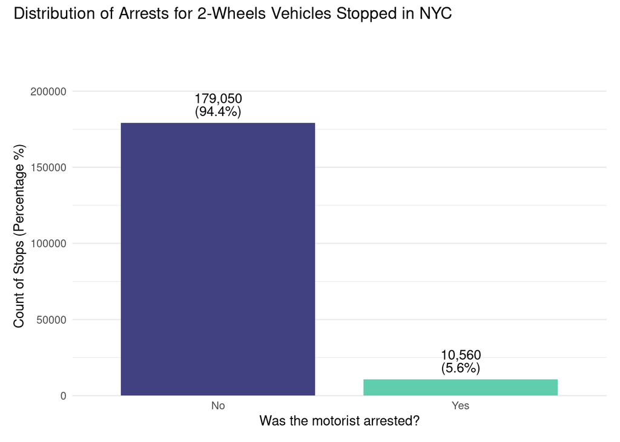

```r
p1 <- plot_binary_bar(
  vehstops, arrested,
  "No", "Yes",
  "Was the motorist arrested?", "Count of Stops (Percentage %)", ""
)

row1 <- p1

row1 +
plot_annotation(title = "Distribution of Arrests for 2-Wheels Vehicles Stopped in NYC") &
theme(legend.position = "bottom")
```

What can we say?

- **Key finding**: The dataset, for 2 wheels-vehicles, **exhibits extreme class imbalance**. Arrests are highly sparse, representing only approximately $5.6\%$ of the times ($10,560$ “Yes” out of $189,610$ total records).
- **Interpretation**: The target constitutes “rare event” when we contemplate the stops of 2-wheels vehicles. In fact, they remain an infrequent occurrence with respect to the total volume of police stops.
- **Comment**: The high class disparity *makes accuracy a limiting metric* for our models’ evaluation. This is due to the fact a predictive model aiming for accuracy could achieve a high score by simply classifying every stop as “No”. Therefore, it completely fails to capture the what characterizes an arrest after a stop. This is also sub-optimal for our research, as capturing the true patterns is what drives our investigation towards enforcement bias.
- **Proposed Action**: Although we could employ cost-sensitive learning models, this is outside the scope of the course. As an alternative, we will **employ stratified down-sampling of the majority class** (“No”) to create a balanced training set, ensuring compatibility across all models (LDA, QDA, KNN, etc…). For the **GLM-based models** (Logistic, Lasso, Ridge), we will specifically **utilize observation weighting within the likelihood function** to account for the class disparity. Finally, we will move away from the default $0.5$ classification threshold, **optimizing the decision boundary based on the Precision-Recall curve** to ensure our model maintains sensitivity to the minority class (“Yes”).

## Geospatial predictors

### Area

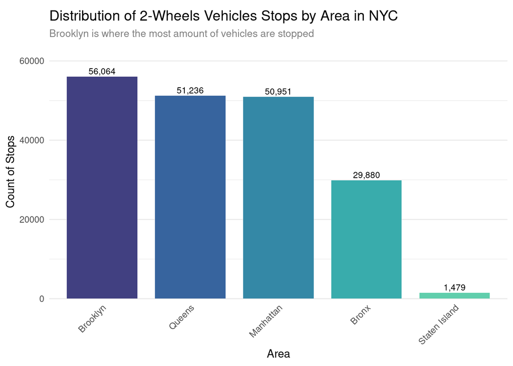

```r
plot_univariate_cat(
  DF = vehstops,
  FEATURE = area,
  X_LABEL = "Area",
  TITLE = "Distribution of 2-Wheels Vehicles Stops by Area in NYC",
  SUBTITLE = "Brooklyn is where the most amount of vehicles are stopped",
  order_by = "freq"
)
```

What can we say?

- **Key finding**: There is a high variance in the volume of stops across areas. We observe three “high-volume” areas (Brooklyn, Queens, and Manhattan) with comparable stop counts (ranging between $50$k and $56$k), one “medium-volume” area (Bronx, $30$k), and a distinct “low-volume” area (Staten Island, $1.5$ k).
- **Interpretation**: The distribution is highly non-uniform, or better, uneven. The lower frequency of stops in the Bronx and Staten Island suggests that geographic location could be a strong predictor of the probability of being stopped (in case the targets’ ratio distributed by area follows a specific pattern).
- **Comment**: From a modeling perspective, this introduces a risk of **overfitting to the high-volume areas**. Since some of the available models (especially KNN or QDA) rely on local neighborhood data or global likelihoods, they will naturally prioritize minimizing errors in the areas with the most observations. Furthermore, the extreme sparsity of the Staten Island group may lead to high variance in the parameter estimates for that specific categorical level, potentially skewing the coefficients for the area predictor. The visualization succeeds in highlighting a pattern, but it leaves the causal mechanisms open to speculation.
- **Proposed Action**: We still need to check its association with demographic predictors. Also, we still want to explore the finer-grained version of this geographical predictor (`boro`), which may achieve better results in the models. If using **Lasso or Ridge regression**, we will carefully tune the penalty parameter ($\lambda$) to ensure that the “Area” coefficients are not inflated/suppressed due to the sample size difference.

### Borough

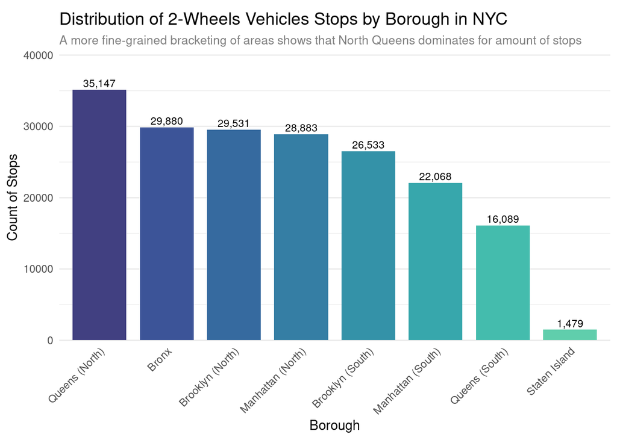

```r
plot_univariate_cat(
  DF = vehstops,
  FEATURE = boro,
  X_LABEL = "Borough",
  TITLE = "Distribution of 2-Wheels Vehicles Stops by Borough in NYC",
  SUBTITLE = "A more fine-grained bracketing of areas shows that North Queens dominates for amount of stops"
)
```

What can we say?

- **Key finding**: The comparison reveals that while “Staten Island” is uniformly sparse, boroughs like “Queens” and “Manhattan” are internally heterogeneous.
- **Interpretation**: If the arrest rate in “North West Queens” (a high-volume area) is statistically distinct from “South Queens,” the `area` variable acts as a source of **aggregation bias**. By averaging these rates, we lose the model’s ability to differentiate between high-risk and low-risk zones within the same borough (potentially obscuring patterns of excessive enforcement). On the other hand, in a regression or classification context, this means our parameter estimates for these low-frequency categories will likely suffer from high variance and wide confidence intervals, making them unreliable indicators of systematic enforcement bias.
- **Comment**: Discarding granularity prematurely is a risk. If a specific sub-borough has a disproportionately higher event rate than its parent borough, the model will fail to capture that specific hotspot. We should not treat granularity as “noise” until we have empirical evidence that the target ratios are homogeneous within the boroughs. In fact, if the target ratio differs significantly between “North West Queens” and “South Queens,” aggregating them into a single “Queens” category would indeed “wash out” a genuine, predictive signal, resulting in an under-fitted model.
- **Proposed Action**: As previously stated, we wish to plot the arrest rate for each borough level, as well for the areas. Then, based on our observations, we could train two alternative versions of the same model using `area` and `boro`. In fact, we could employ means of model comparison (for instance, Stratified K-fold Cross Validation) and, in case the granular version yields lower CV error, we may be able to discard the hypothesis of introducing noise/variability.

### Latitude and Longitude for Stop Density

For what concerns these two predictors, we will use the to plot a spatial heat map of the stops with these values available.

```r
nyc_map <- counties(state = "NY", cb = TRUE) %>%
  filter(NAME %in% c("Bronx", "Kings", "New York", "Queens", "Richmond"))
```

[output not shown]

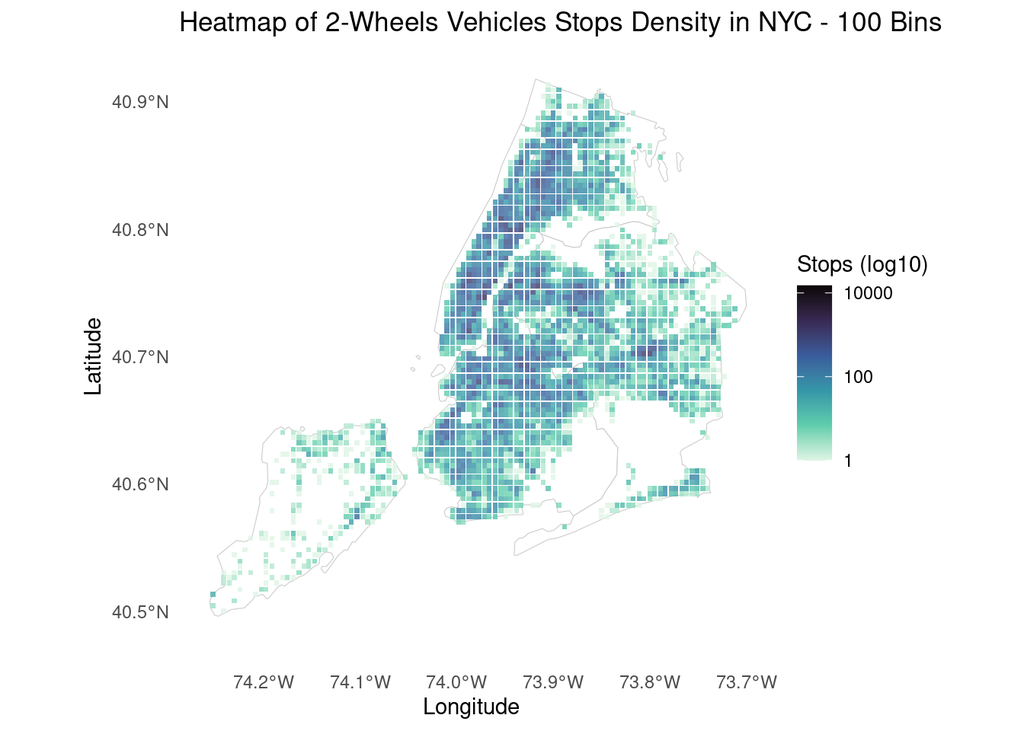

```r
bins <- 100
lon_breaks <- seq(-74.26, -73.71, length.out = bins + 1)
lat_breaks <- seq(40.48, 40.92, length.out = bins + 1)

grid_sum <- vehstops %>%
  filter(!is.na(longitude) & !is.na(latitude)) %>%
  mutate(
    xbin = cut(longitude, breaks = lon_breaks, include.lowest = TRUE, right = FALSE),
    ybin = cut(latitude, breaks = lat_breaks, include.lowest = TRUE, right = FALSE)
  ) %>%
  mutate(
    x = as.numeric(gsub(".*\\[(.*),.*", "\\1", xbin)) + (lon_breaks[2] - lon_breaks[1])/2,
    y = as.numeric(gsub(".*\\[(.*),.*", "\\1", ybin)) + (lat_breaks[2] - lat_breaks[1])/2
  ) %>%
  group_by(x, y) %>%
  summarise(n = n(), .groups = "drop")

ggplot() +
  geom_sf(data = nyc_map, fill = "white", color = "grey80", size = 0.2) +
  geom_tile(data = grid_sum, aes(x, y, fill = n), alpha = 0.8) +
  scale_fill_viridis_c(trans = "log10", name = "Stops (log10)", option = "mako", direction = -1) +
  coord_sf(xlim = c(-74.26, -73.71), ylim = c(40.48, 40.92)) +
  theme_minimal() +
  theme(panel.grid = element_blank()) +
  labs(title = "Heatmap of 2-Wheels Vehicles Stops Density in NYC - 100 Bins", x = "Longitude", y = "Latitude")
```

What can we say?

- **Key finding**: The heatmap reveals a highly heterogeneous spatial distribution, characterized by distinct high-density hotspots.
- **Interpretation**: This spatial clustering indicates that police enforcement is not randomly distributed but it is likely to be following the major traffic arteries.
- **Proposed Action**: To prevent data leakage we cannot just include then in the models. These two predictors will be later removed.

## Time-related predictors

### Year

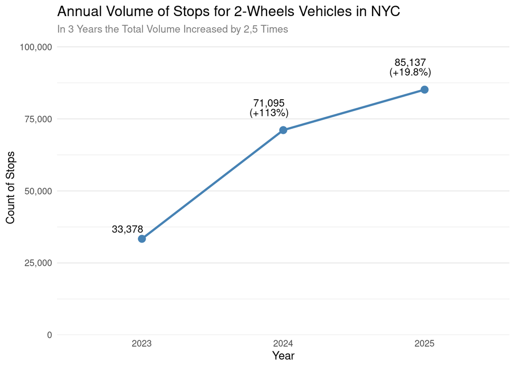

```r
vehstops %>%
  filter(!is.na(year)) %>%
  count(year) %>%
  mutate(year = as.numeric(as.character(year))) %>%
  arrange(year) %>%
  mutate(
    prev_n = lag(n), pct_change = (n - prev_n) / prev_n * 100,
    label_text = ifelse(
      is.na(pct_change),
      comma(n),
      paste0(comma(n), "\n(", ifelse(pct_change > 0, "+", ""), round(pct_change, 1), "%)")
    )) %>%
  ggplot(aes(x = factor(year), y = n, group = 1)) +
  geom_line(color = "steelblue", linewidth = 1) +
  geom_point(color = "steelblue", size = 3) +
  geom_text(aes(label = label_text), vjust = -0.8, nudge_x = -0.1, size = 3.5, lineheight = 0.8) +
  scale_y_continuous(labels = comma, limits = c(0, NA), expand = expansion(mult = c(0, 0.2))) +
  theme_minimal() +
  theme(
    panel.grid.major.x = element_blank(),
    plot.title = element_text(size = 14),
    plot.subtitle = element_text(size = 10, color = "grey50")
    ) +
  labs(
    title = "Annual Volume of Stops for 2-Wheels Vehicles in NYC",
    subtitle = "In 3 Years the Total Volume Increased by 2,5 Times",
    x = "Year", y = "Count of Stops"
    )
```

What can we say?

- **Key finding**: There has been a significant, multi-year surge in the volume of police stops involving 2-wheeled vehicles, with the number of encounters increasing from $33$k in $2023$ to $85$k in $2025$.
- **Interpretation**: The growth trajectory is non-linear. The $113\%$ jump between $2023$ and $2024$ represents a massive inflection point, which is suggesting either a shift in departmental priority or a new legislation targeting these vehicles. On the other hand, the $19.8\%$ increase in 2025 indicates that while activity is still rising, the rate of acceleration is starting to stabilize.
- **Comment**: The visualization clearly demonstrates that the “public exposure” to these stops is increasing. However, since the dataset analyzed was aggregated by 2-wheels vehicles, we could be seeing the result of policies regarding a specific subset. Plus, 3 years is not a sufficient time span for us to deliver some substantial proof.
- **Proposed Action**: From a modeling perspective, we need to ensure that the temporal variable `year` does not introduce confounding effects when evaluating our target variable. We will include `year` as a categorical factor or dummy variable in our classification models to control for these shifting annual baselines.

In fact, we found the article [“New York City Council Votes to Pass New E-Bike Safety Rules in Continued Effort to Address the Dangers of Lithium-Ion Batteries”](https://council.nyc.gov/press/2024/02/28/2564/) published in February 28, 2024. From its content, we could justify the raise in volume as natural consequence to new laws being put in place.

### Month

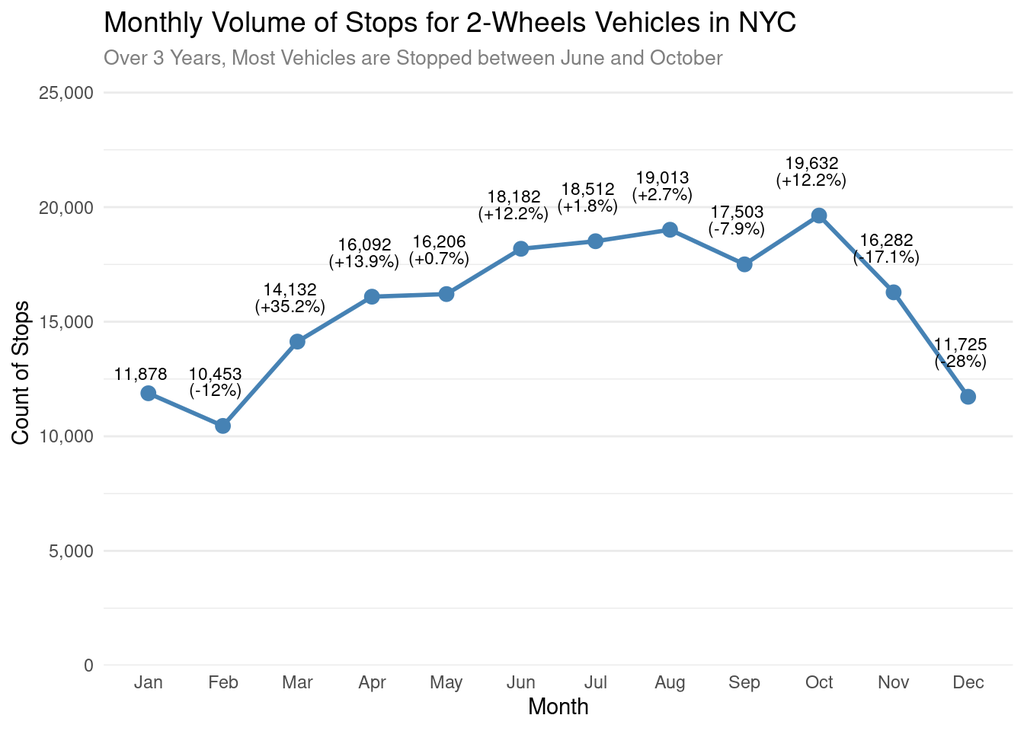

```r
month_data <- vehstops %>%
  filter(!is.na(month)) %>%
  count(month) %>%
  mutate(month = factor(month, levels = 1:12)) %>%
  arrange(month) %>%
  mutate(
    prev_n = lag(n), pct_change = (n - prev_n) / prev_n * 100,
    label_text = ifelse(
      is.na(pct_change), comma(n),
      paste0(comma(n), "\n(", ifelse(pct_change > 0, "+", ""), round(pct_change, 1), "%)"))
  )

month_data %>%
  ggplot(aes(x = month, y = n, group = 1)) +
  geom_line(color = "steelblue", linewidth = 1) +
  geom_point(color = "steelblue", size = 3) +
  geom_text(aes(label = label_text), vjust = -1, nudge_x = -0.1, size = 3, lineheight = 0.8) +
  scale_x_discrete(labels = month.abb) +
  scale_y_continuous(labels = comma, limits = c(0, NA), expand = expansion(mult = c(0, 0.3))) +
  theme_minimal() +
  theme(
    panel.grid.major.x = element_blank(),
    plot.title = element_text(size = 14),
    plot.subtitle = element_text(color = "grey50", size = 10)
  ) +
  labs(
    title = "Monthly Volume of Stops for 2-Wheels Vehicles in NYC",
    subtitle = "Over 3 Years, Most Vehicles are Stopped between June and October",
    x = "Month",
    y = "Count of Stops"
  )
```

What can we say?

- **Key finding**: The data exhibits strong seasonality for bikers, with stop volumes peaking in a plateau between June and October (roughly $18$k - $19$k stops/month). Enforcement bottoms out in the winter, with the sharpest declines occurring in November ($-17\%$) and December ($-28\%$).
- **Interpretation**: As temperatures rise, more 2-wheeled vehicles are on the road, increasing the opportunity for police to conduct stops. The “plateau” from June through October suggests that (once the weather is consistently warm) the trend hits a saturation point, and enforcement activity maintains a high baseline.
- **Comment**: It would be easy to state that, the decline in stops during winter is likely due to **reduced vehicle usage** rather than a change in police behavior. However, both mechanisms are not distinguishable from the data alone.
- **Proposed Action**: Given this clear seasonal pattern, we ensure our predictive models to include this time-related feature.

Let us see this with respect to the year

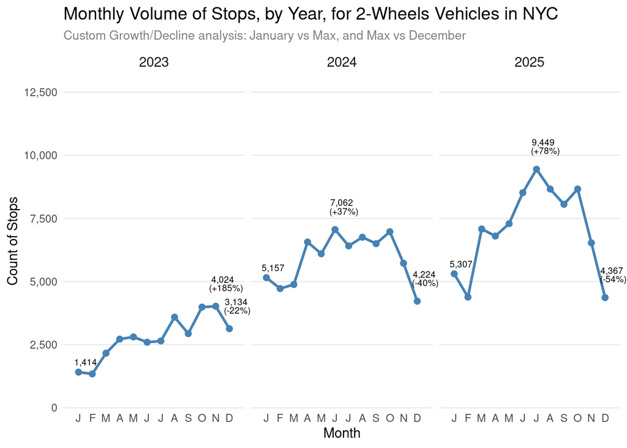

```r
plot_data <- vehstops %>%
  filter(!is.na(year) & !is.na(month)) %>%
  count(year, month) %>%
  mutate(month = factor(month, levels = 1:12)) %>%
  group_by(year) %>%
  mutate(
    n_jan = n[month == 1],
    n_max = max(n),
    is_max = n == n_max,
    pct_max = round((n - n_jan) / n_jan * 100, 0),
    pct_dec = round((n - n_max) / n_max * 100, 0),

    label_text = case_when(
      month == 1 ~ comma(n),
      is_max ~ paste0(comma(n), "\n(", ifelse(pct_max > 0, "+", ""), pct_max, "%)"),
      month == 12 ~ paste0(comma(n), "\n(", pct_dec, "%)"),
      TRUE ~ ""
    )
  )

# Faceted plot
plot_data %>%
  ggplot(aes(x = month, y = n, group = 1)) +
  geom_line(color = "steelblue", linewidth = 1) +
  geom_point(color = "steelblue", size = 2) +
  geom_text(aes(label = label_text), vjust = -1, hjust = 0.2, size = 2.5, lineheight = 0.8) +
  facet_wrap(~year, nrow = 1) +
  scale_x_discrete(
    labels = c("J", "F", "M", "A", "M", "J", "J", "A", "S", "O", "N", "D"),
    expand = expansion(mult = c(0.1, 0.1))
    ) +
  scale_y_continuous(labels = comma, limits = c(0, NA), expand = expansion(mult = c(0, 0.4))) +
  coord_cartesian(clip = "off") +
  theme_minimal() +
  theme(
    panel.grid.major.x = element_blank(),
    panel.grid.minor = element_blank(),
    plot.title = element_text(size = 14),
    plot.subtitle = element_text(color = "grey50", size = 10),
    strip.text = element_text(size = 11)
  ) +
  labs(
    title = "Monthly Volume of Stops, by Year, for 2-Wheels Vehicles in NYC",
    subtitle = "Custom Growth/Decline analysis: January vs Max, and Max vs December",
    x = "Month",
    y = "Count of Stops"
  )
```

### Checking out `hot_season`

```r
vehstops <- vehstops %>%
  mutate(hot_season = ifelse(month %in% 4:10, 1, 0))
```

Now, for plotting

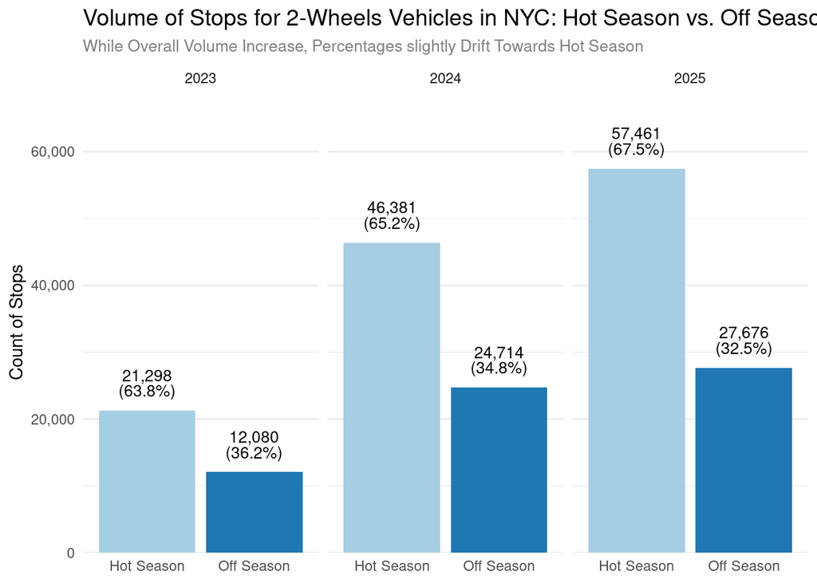

```r
plot_data <- vehstops %>%
  filter(!is.na(year) & !is.na(month)) %>%
  mutate(
    is_hot_season = ifelse(month %in% 4:10, "Hot Season", "Off Season"),
    is_hot_season = factor(is_hot_season, levels = c("Hot Season", "Off Season"))
  ) %>%
  count(year, is_hot_season) %>%
  group_by(year) %>%
  mutate(
    year_total = sum(n),
    pct = n / year_total,
    label_text = paste0(comma(n), "\n(", round(pct * 100, 1), "%)")
  )

plot_data %>%
  ggplot(aes(x = is_hot_season, y = n, fill = is_hot_season)) +
  geom_col(show.legend = FALSE) +
  facet_wrap(~year, nrow = 1) +
  geom_text(aes(label = label_text), vjust = -0.5, size = 3.5, lineheight = 0.8) +
  scale_y_continuous(labels = comma, expand = expansion(mult = c(0, 0.2))) +
  scale_fill_brewer(palette = "Paired") +
  theme_minimal() +
  theme(
    panel.grid.major.x = element_blank(),
    plot.title = element_text(size = 14),
    plot.subtitle = element_text(color = "grey50", size = 10)
  ) +
  labs(
    title = "Volume of Stops for 2-Wheels Vehicles in NYC: Hot Season vs. Off Season",
    subtitle = "While Overall Volume Increase, Percentages slightly Drift Towards Hot Season",
    x = NULL,
    y = "Count of Stops"
  )
```

What can we say?

- **Key finding**: Total enforcement volume is surging but, more importantly, the enforcement pattern is slowly becoming **increasingly concentrated** in the “Hot Season.” In fact, while the hot season accounted for $64\%$ of stops in $2023$, it reached $68\%$ of stops in $2025$.
- **Interpretation**: The growth in stops is not uniform throughout the year. The rising percentage indicates that the “Hot Season” (April-Oct) is becoming a disproportionately larger driver of total annual stops year-over-year. However, the $3$ year span of the data does not make this definite.
- **Comment**: This plot confirms that `hot_season` could be a “high-signal” feature. On the other hand, this cannot be just inferred by looking at the year.

### Dow/Weekday, Day and Doy

We have decided to exclude ‘Day of Month’ (`day`) and ‘Day of Year’ (`doy`) from our feature set to mitigate ‘calendar artifact’ bias.

As we can see below, the variation in month length creates false activity dips for end-of-month dates

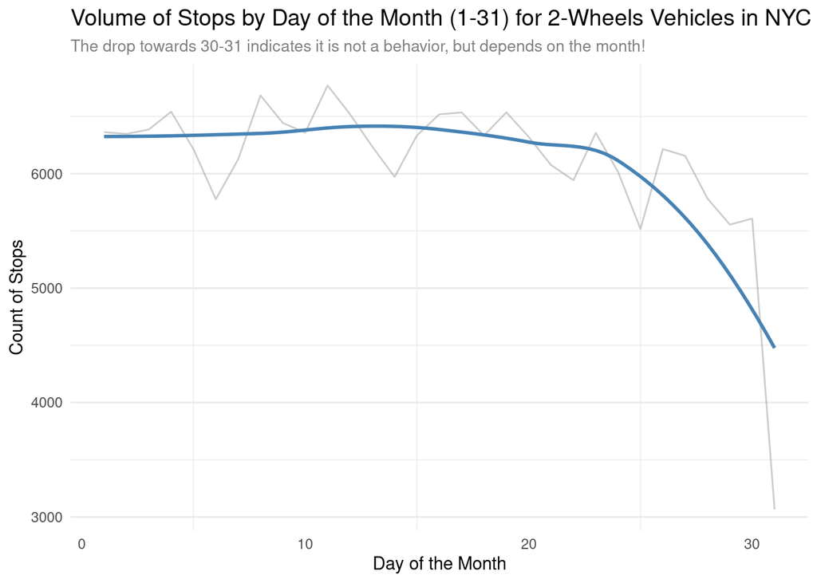

```r
vehstops %>%
  filter(!is.na(day)) %>%
  count(day) %>%
  ggplot(aes(x = day, y = n)) +
  geom_line(color = "grey60", alpha = 0.5) +
  geom_smooth(method = "loess", color = "steelblue", se = FALSE) +
  theme_minimal() +
   theme(
    panel.grid.major.x = element_blank(),
    plot.title = element_text(size = 14),
    plot.subtitle = element_text(color = "grey50", size = 10)
  ) +
  labs(title = "Volume of Stops by Day of the Month (1-31) for 2-Wheels Vehicles in NYC",
       subtitle = "The drop towards 30-31 indicates it is not a behavior, but depends on the month!",
       x = "Day of the Month", y = "Count of Stops")
```

Furthermore, `doy` variable suffers from inconsistent data density.

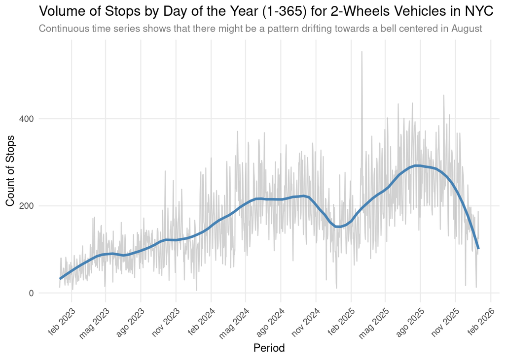

```r
plot_data <- vehstops %>%
  mutate(date = as.Date(paste(year, month, day, sep = "-"))) %>%
  count(date)

plot_data %>%
  ggplot(aes(x = date, y = n)) +
  geom_line(color = "grey70", alpha = 0.6, linewidth = 0.5) +
  geom_smooth(method = "loess", span = 0.2, color = "steelblue", se = FALSE, linewidth = 1.2) +
  scale_x_date(date_breaks = "3 months", date_labels = "%b %Y") +
  theme_minimal() +
  theme(
    panel.grid.minor = element_blank(),
    axis.text.x = element_text(angle = 45, hjust = 1),
    plot.title = element_text(size = 14),
    plot.subtitle = element_text(color = "grey50", size = 10)
  ) +
  labs(
    title = "Volume of Stops by Day of the Year (1-365) for 2-Wheels Vehicles in NYC",
    subtitle = "Continuous time series shows that there might be a pattern drifting towards a bell centered in August",
    x = "Period",
    y = "Count of Stops"
  )
```

While we observe a consistent seasonal clustering peaking in late summer, our current 3-year dataset captures three seasonal cycles. This is sufficient to identify a recurring pattern, but insufficient to establish it as a long-term trend.

The next plot, demonstrates high daily volatility (indicated by the grey jitter) that obscures the underlying seasonal trend (the blue trend line). Because the daily fluctuation is relative to the overall pattern, including ‘Day of Year’ as a feature risks overfitting.

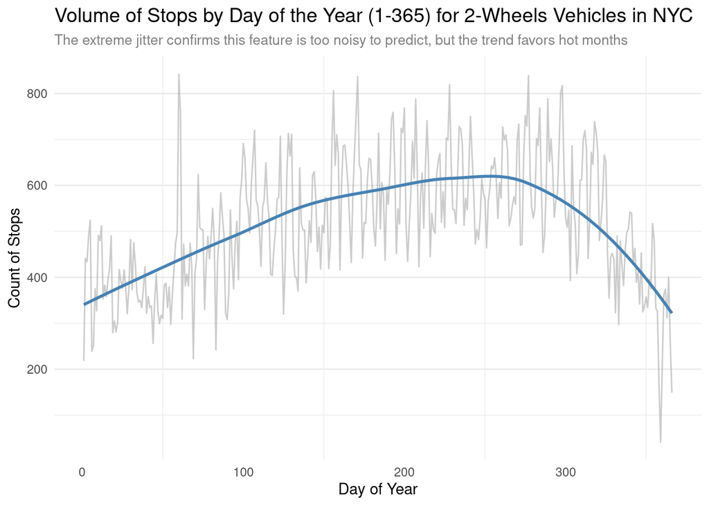

```r
vehstops %>%
  filter(!is.na(doy)) %>%
  count(doy) %>%
  ggplot(aes(x = doy, y = n)) +
  geom_line(color = "grey60", alpha = 0.5) +
  geom_smooth(method = "loess", color = "steelblue", se = FALSE) +
  theme_minimal() +
   theme(
    panel.grid.major.x = element_blank(),
    plot.title = element_text(size = 14),
    plot.subtitle = element_text(color = "grey50", size = 10)
  ) +
  labs(title = "Volume of Stops by Day of the Year (1-365) for 2-Wheels Vehicles in NYC",
       subtitle = "The extreme jitter confirms this feature is too noisy to predict, but the trend favors hot months",
       x = "Day of Year", y = "Count of Stops")
```

Finally, these granular temporal markers are prone to overfitting. Excluding them allows the model to focus on more robust predictors, such as seasonality and weekly rhythms.

On the other hand, we can study the “Day of the Week” which usually abstract better.

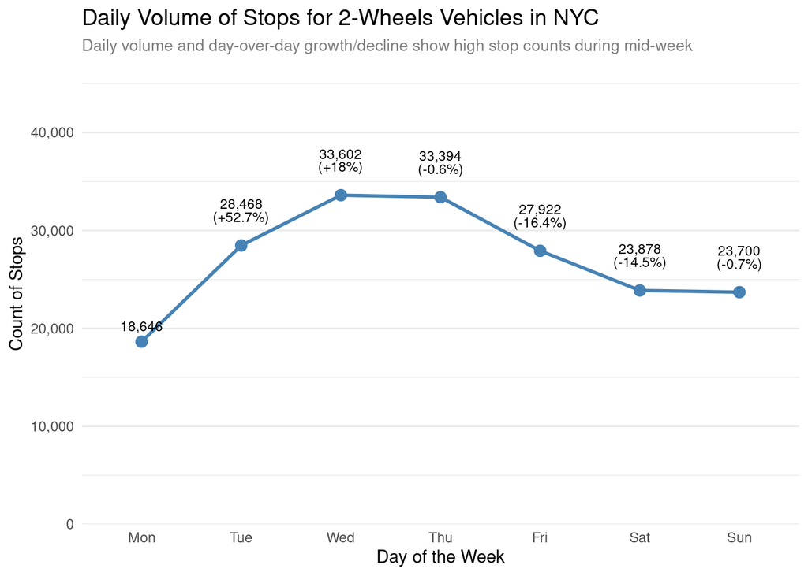

```r
vehstops %>%
  filter(!is.na(dow)) %>%
  count(dow) %>%
  mutate(
    dow = factor(dow, levels = 1:7,
                 labels = c("Mon", "Tue", "Wed", "Thu", "Fri", "Sat", "Sun")),
    pct_change = (n - lag(n)) / lag(n) * 100,
    label_text = ifelse(is.na(pct_change),
                        comma(n),
                        paste0(comma(n), "\n(", ifelse(pct_change > 0, "+", ""), round(pct_change, 1), "%)"))
  ) %>%
  ggplot(aes(x = dow, y = n, group = 1)) +
  geom_line(color = "steelblue", linewidth = 1) +
  geom_point(color = "steelblue", size = 3) +
  geom_text(aes(label = label_text), vjust = -1, size = 3, lineheight = 0.8) +
  scale_y_continuous(labels = comma,
                     limits = c(0, NA),
                     expand = expansion(mult = c(0, 0.4))) +
  theme_minimal() +
  theme(
    panel.grid.major.x = element_blank(),
    plot.title = element_text(size = 14),
    plot.subtitle = element_text(color = "grey50", size = 10)
  ) +
  labs(
    title = "Daily Volume of Stops for 2-Wheels Vehicles in NYC",
    subtitle = "Daily volume and day-over-day growth/decline show high stop counts during mid-week",
    x = "Day of the Week",
    y = "Count of Stops"
  )
```

What can we say?

- **Key finding**: Enforcement activity follows a distinct “Mid-Week Peak” cycle. The volume starts at its lowest on Monday, raises aggressively ($+52.7\%$) into Tuesday, peaks on Wednesday/Thursday, and then declines toward the weekend.
- **Comment**: This pattern *might* suggests that these stops are primarily linked to **commercial usage** (ex: food delivery/courier services) rather than recreational riding. In fact, it would be easier to think that recreational riders typically peak on weekends, while here we find that enforcement is targeting “work-hour” traffic as the volume drops on the weekend. The interpretation is plausible but not derivable from these counts alone.
- **Proposed Action**: We may keep `weekday` as the new `day` in the model. Also we need first to check the signal from other indicators previously built.

### Hour and Time Bracket

First of all we look at the overall cycle of stops volume

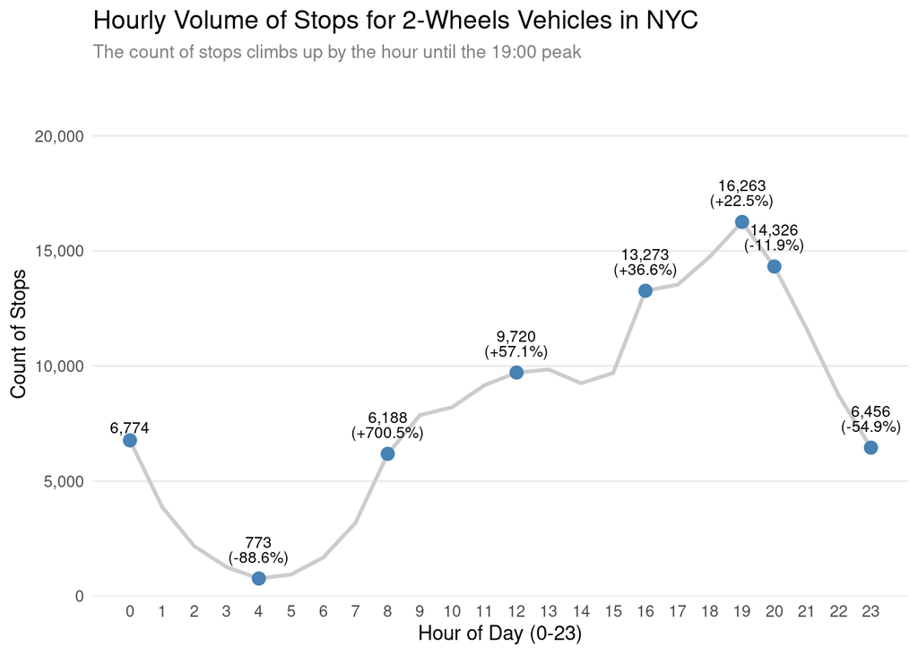

```r
hours_to_show <- c(0, 4, 8, 12, 16, 19, 20, 23)

full_data <- vehstops %>%
  filter(!is.na(hour)) %>%
  count(hour)

highlight_data <- full_data %>%
  filter(hour %in% hours_to_show) %>%
  arrange(hour) %>%
  mutate(
    pct_change = (n - lag(n)) / lag(n) * 100,
    label_text = ifelse(
      is.na(pct_change),
      comma(n),
      paste0(comma(n), "\n(", ifelse(pct_change > 0, "+", ""), round(pct_change, 1), "%)"))
  )

ggplot() +
  geom_line(data = full_data, aes(x = hour, y = n), color = "grey80", linewidth = 1) +
  geom_point(data = highlight_data, aes(x = hour, y = n), color = "steelblue", size = 3) +
  geom_text(data = highlight_data, aes(x = hour, y = n, label = label_text),
            vjust = -0.6, size = 3, lineheight = 0.8) +
  scale_x_continuous(breaks = 0:23) +
  scale_y_continuous(labels = comma, limits = c(0, NA), expand = expansion(mult = c(0, 0.4))) +
  theme_minimal() +
  theme(
    panel.grid.major.x = element_blank(),
    panel.grid.minor = element_blank(),
    plot.title = element_text(size = 14),
    plot.subtitle = element_text(color = "grey50", size = 10)
  ) +
  labs(
    title = "Hourly Volume of Stops for 2-Wheels Vehicles in NYC",
    subtitle = "The count of stops climbs up by the hour until the 19:00 peak",
    x = "Hour of Day (0-23)",
    y = "Count of Stops"
  )
```

What can we say? In our opinion this looks like a “sine wave broken by a bridge”. To be more precise:

- **Key finding**: Enforcement volume is characterized by a “fractured” daily cycle. It follows a predictable overnight decline and morning ascent ($0:00-12:00$), but is interrupted by a distinct midday plateau ($12:00-15:00$) before reaching an aggressive evening peak at $19:00$.
- **Interpretation**: This suggests that the enforcement cycle is divided into two distinct operational phases: the **Morning Phase** (likely commuter-driven) and the **Evening Phase** (likely delivery/service-driven), while the plateau is the “bridge” between these two. The variability during $10:00$ to $15:00$ is limited because the amount of vehicles on the road probably remains stable, as well as the police work.
- **Proposed Action**: We will maintain `hour` as a temporal feature in our predictive framework. As an alternative, we *could* try to properly capture this pattern. For instance, we could **transform the continuous hour variable using a periodic basis function**, so that it becomes a continuous feature.

Before anything else, let us see whether this cycle changed throughout the years.

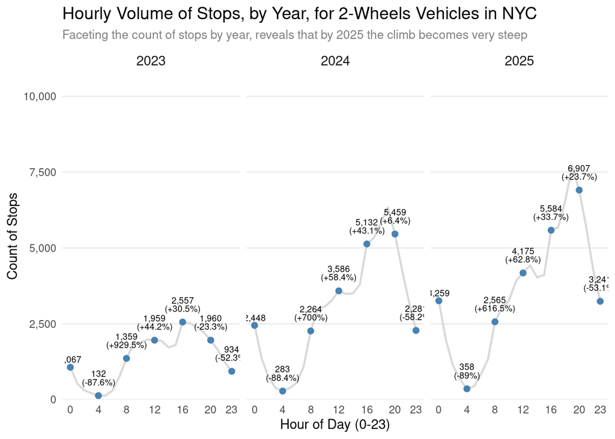

```r
hours_to_show <- c(0, 4, 8, 12, 16, 20, 23)

full_data <- vehstops %>%
  filter(!is.na(year) & !is.na(hour)) %>%
  count(year, hour)

highlight_data <- full_data %>%
  filter(hour %in% hours_to_show) %>%
  group_by(year) %>%
  arrange(hour) %>%
  mutate(
    pct_change = (n - lag(n)) / lag(n) * 100,
    label_text = ifelse(
      is.na(pct_change),
      comma(n),
      paste0(comma(n), "\n(", ifelse(pct_change > 0, "+", ""), round(pct_change, 1), "%)"))
  )

ggplot() +
  geom_line(data = full_data, aes(x = hour, y = n), color = "grey85", linewidth = 0.8) +
  geom_point(data = highlight_data, aes(x = hour, y = n), color = "steelblue", size = 2) +
  geom_text(data = highlight_data, aes(x = hour, y = n, label = label_text),
            vjust = -0.7, size = 2.5, lineheight = 0.8) +
  facet_wrap(~year, nrow = 1) +
  scale_x_continuous(breaks = c(0, 4, 8, 12, 16, 20, 23)) +
  scale_y_continuous(labels = comma, limits = c(0, NA), expand = expansion(mult = c(0, 0.4))) +
  theme_minimal() +
  theme(
    panel.grid.major.x = element_blank(),
    panel.grid.minor = element_blank(),
    plot.title = element_text(size = 14),
    plot.subtitle = element_text(color = "grey50", size = 10),
    strip.text = element_text(size = 11)
  ) +
  labs(
    title = "Hourly Volume of Stops, by Year, for 2-Wheels Vehicles in NYC",
    subtitle = "Faceting the count of stops by year, reveals that by 2025 the climb becomes very steep",
    x = "Hour of Day (0-23)",
    y = "Count of Stops"
  )
```

What can we say?

- **Key finding**: While $2023$ enforcement peaked at $16:00$ ($4:00$ PM), the peak has decisively migrated to $19:00-20:00$ ($7:00-8:00$ PM) in $2024$ and $2025$. Additionally, the volume near the $19:00-20:00$ peak has nearly tripled between $2023$ and $2025$.
- **Interpretation**: This suggests that the primary targets of enforcement (likely delivery riders) are increasingly active later into the evening, or that (since $2024$) enforcement volume and trend has taken a new look. The “Evening Rush” ($16:00-20:00$) is the clear driver of the total volume increase.
- **Comment**: This may confirm our previous idea concerning the article cited above. It is possible that new regulations directly translated into increased amount of stops by the police.

Now let us see if the hot season might shift this cycle

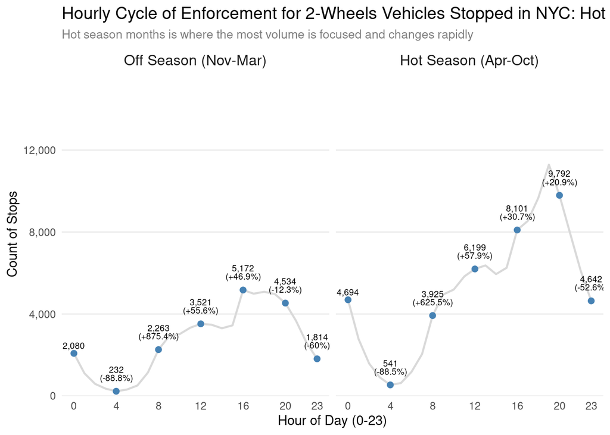

```r
plot_data_full <- vehstops %>%
  mutate(
    hot_season = ifelse(month %in% 4:10, 1, 0),
    hot_season_label = factor(hot_season, levels = c(0, 1),
                              labels = c("Off Season (Nov-Mar)", "Hot Season (Apr-Oct)"))
  ) %>%
  filter(!is.na(hour))

full_data <- plot_data_full %>%
  count(hot_season_label, hour)

hours_to_show <- c(0, 4, 8, 12, 16, 20, 23)

highlight_data <- full_data %>%
  filter(hour %in% hours_to_show) %>%
  group_by(hot_season_label) %>%
  arrange(hour) %>%
  mutate(
    pct_change = (n - lag(n)) / lag(n) * 100,
    label_text = ifelse(is.na(pct_change),
                        comma(n),
                        paste0(comma(n), "\n(", ifelse(pct_change > 0, "+", ""), round(pct_change, 1), "%)"))
  )

ggplot() +
  geom_line(data = full_data, aes(x = hour, y = n), color = "grey85", linewidth = 0.8) +
  geom_point(data = highlight_data, aes(x = hour, y = n), color = "steelblue", size = 2) +
  geom_text(data = highlight_data, aes(x = hour, y = n, label = label_text),
            vjust = -0.7, size = 2.5, lineheight = 0.8) +
  facet_wrap(~hot_season_label, nrow = 1) +
  scale_x_continuous(breaks = c(0, 4, 8, 12, 16, 20, 23)) +
  scale_y_continuous(labels = comma, limits = c(0, NA), expand = expansion(mult = c(0, 0.4))) +
  theme_minimal() +
  theme(
    panel.grid.major.x = element_blank(),
    panel.grid.minor = element_blank(),
    plot.title = element_text(size = 14),
    plot.subtitle = element_text(color = "grey50", size = 10),
    strip.text = element_text(size = 12)
  ) +
  labs(
    title = "Hourly Cycle of Enforcement for 2-Wheels Vehicles Stopped in NYC: Hot Season vs. Off Season",
    subtitle = "Hot season months is where the most volume is focused and changes rapidly",
    x = "Hour of Day (0-23)",
    y = "Count of Stops"
  )
```

Let us check the time brackets previously built.

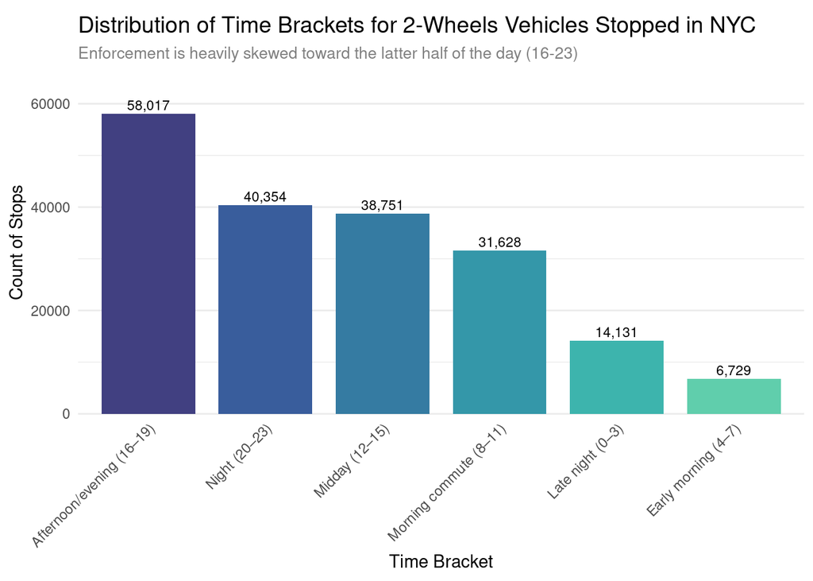

```r
plot_univariate_cat(
  DF = vehstops,
  FEATURE = time_bracket,
  X_LABEL = "Time Bracket",
  TITLE = "Distribution of Time Brackets for 2-Wheels Vehicles Stopped in NYC",
  SUBTITLE = "Enforcement is heavily skewed toward the latter half of the day (16-23)"
)
```

What can we say?

- **Key finding**: The “Afternoon/evening” ($16-19$) and “Night” ($20-23$) brackets collectively account for the majority of stops, with the afternoon/evening block acting as the dominant peak.
- **Interpretation**: This confirms that the “Evening Migration” we observed in the previous charts is a structural trend. Also, it confirms that our buckets align well with the data.
- **Proposed Action**: We can maintain our existing `time_bracket` exactly it is.

Also, we are going to drop minute as its level of granularity cannot be properly included in the dataset.

## Motorist related predictors

### Reported Age

We have mainly one issue here. First, we have many instances of drivers with unknown age,

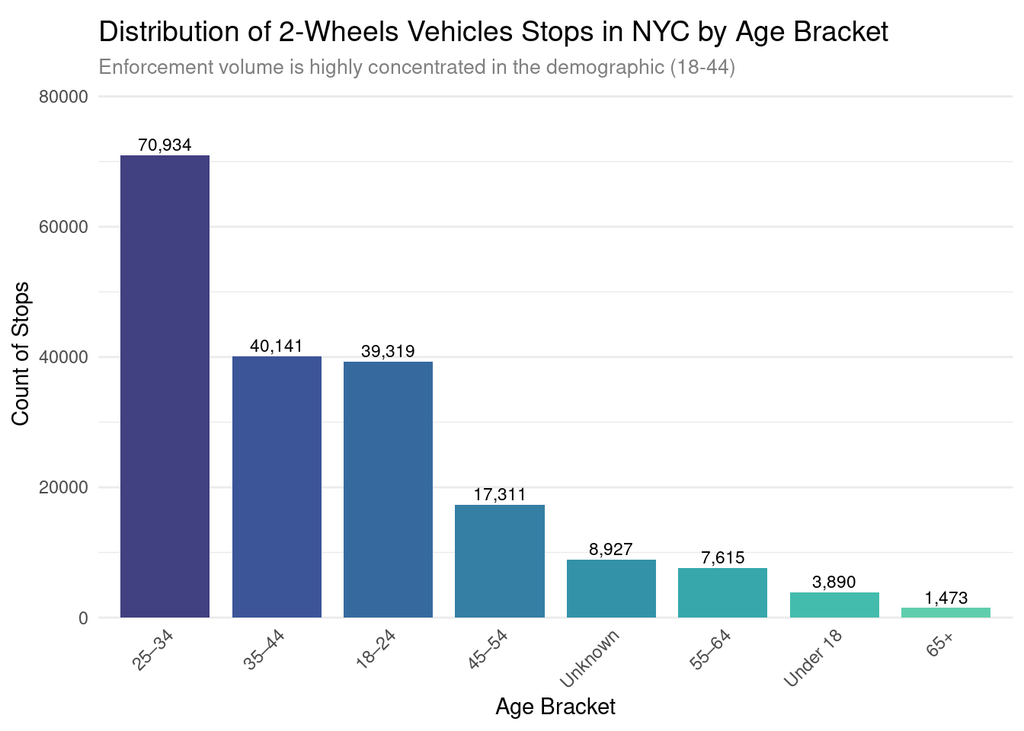

```r
plot_univariate_cat(
  DF = vehstops,
  FEATURE = age_bracket,
  X_LABEL = "Age Bracket",
  TITLE = "Distribution of 2-Wheels Vehicles Stops in NYC by Age Bracket",
  SUBTITLE = "Enforcement volume is highly concentrated in the demographic (18-44)"
)
```

What can we say?

- **Key finding**: A part from, what we decided to put into the subtitle, the “Unknown” age category represents a significant enough portion of the distribution.
- **Interpretation**: The data reflects a clear operational focus on younger drivers, which represent the majority of bikers. There are very few observation for the 65+ bin, which may be considered outliers.
- **Comment**: We do not treat the “Unknown” category as garbage data to be discarded.
- **Proposed Action**: We will retain the “Unknown” category as a level within our `age_bracket` feature rather than using imputation.

And now, let us see how this looks when looking at the full distribution

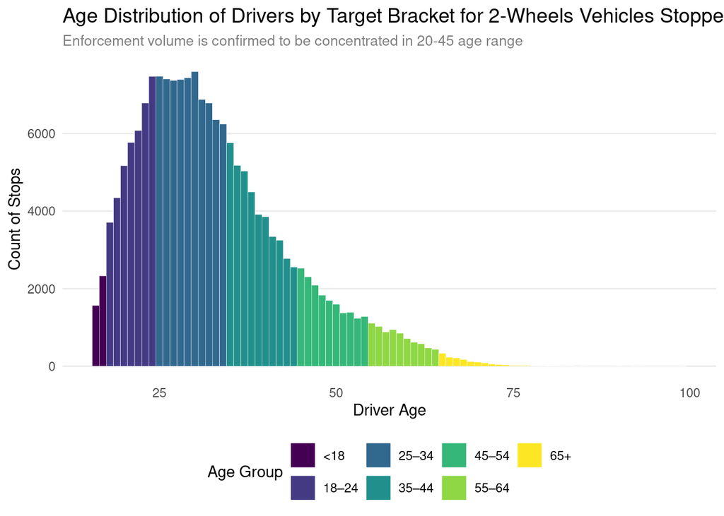

```r
age_data <- vehstops %>%
  filter(!is.na(age), age >= 0, age < 100) %>%
  mutate(
    age_group = case_when(
      age < 18 ~ "<18",
      age >= 18 & age <= 24 ~ "18–24",
      age >= 25 & age <= 34 ~ "25–34",
      age >= 35 & age <= 44 ~ "35–44",
      age >= 45 & age <= 54 ~ "45–54",
      age >= 55 & age <= 64 ~ "55–64",
      age >= 65 ~ "65+"
    ),
    age_group = factor(age_group, levels = c("<18", "18–24", "25–34", "35–44", "45–54", "55–64", "65+"))
  )

ggplot(age_data, aes(x = age, fill = age_group)) +
  geom_histogram(binwidth = 1, color = "white", linewidth = 0.1) +
  scale_fill_viridis_d() +
  theme_minimal() +
   theme(
    panel.grid.major.x = element_blank(),
    panel.grid.minor = element_blank(),
    plot.title = element_text(size = 14),
    plot.subtitle = element_text(color = "grey50", size = 10),
    strip.text = element_text(size = 11)
  ) +
  labs(
    title = "Age Distribution of Drivers by Target Bracket for 2-Wheels Vehicles Stopped in NYC",
    subtitle = "Enforcement volume is confirmed to be concentrated in 20-45 age range",
    x = "Driver Age",
    y = "Count of Stops",
    fill = "Age Group"
  ) +
  theme(legend.position = "bottom") +
  guides(fill = guide_legend(nrow = 2))
```

What can we say?

- **Key finding**: Enforcement is confirmed to be heavily concentrated within the 20-45 age range, with a distinct operational peak occurring in the mid-20s. After age $50$, there is a continuous, rapid decline in stop volume, forming a long and sparse “tail” that extends past $75$.
- **Proposed Action**: We want to filter our dataset to exclude drivers over age $75$. This should enhance the shape of the enforcement curve without losing predictive signal. Furthermore, we may think of collapsing the $55-64$ and $65+$ buckets into a single “55+” category. This should increase the sample size for that bin, ensuring the model has enough data to learn a stable weight for the older demographic.

Let us remove the outliers

```r
# Keep the NAs
vehstops <- vehstops %>%
  filter(age < 76 | is.na(age))
```

From now on we will consider drivers of age in the range 16-75.

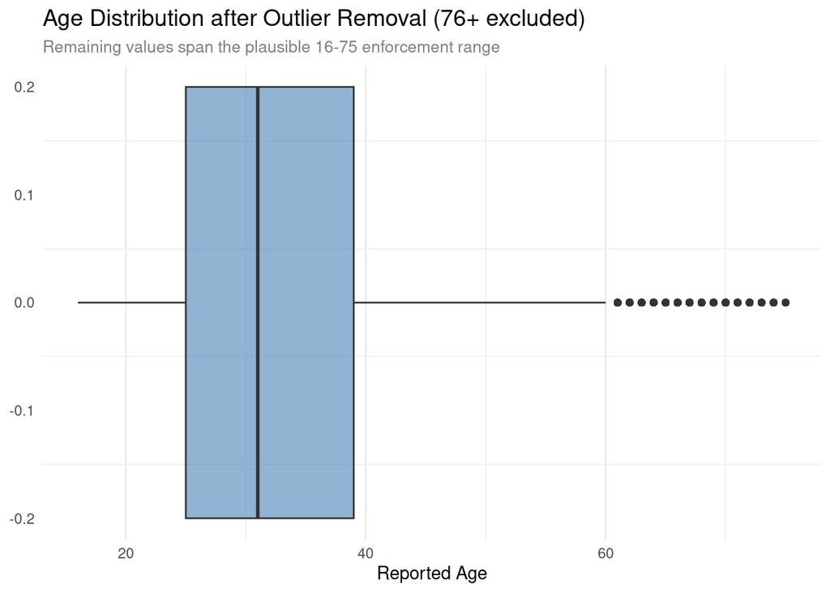

```r
vehstops %>%
  filter(!is.na(age)) %>%
  ggplot(aes(y = age)) +
  geom_boxplot(fill = "steelblue", alpha = 0.6, width = 0.4,
               outlier.size = 1.5, outlier.alpha = 0.4) +
  coord_flip() +
  theme_minimal() +
  theme(
    panel.grid.major.y = element_blank(),
    plot.title = element_text(size = 14),
    plot.subtitle = element_text(color = "grey50", size = 10)
  ) +
  labs(
    title = "Age Distribution after Outlier Removal (76+ excluded)",
    subtitle = "Remaining values span the plausible 16-75 enforcement range",
    y = "Reported Age", x = NULL
  )
```

What can we say?

### Reported Sex

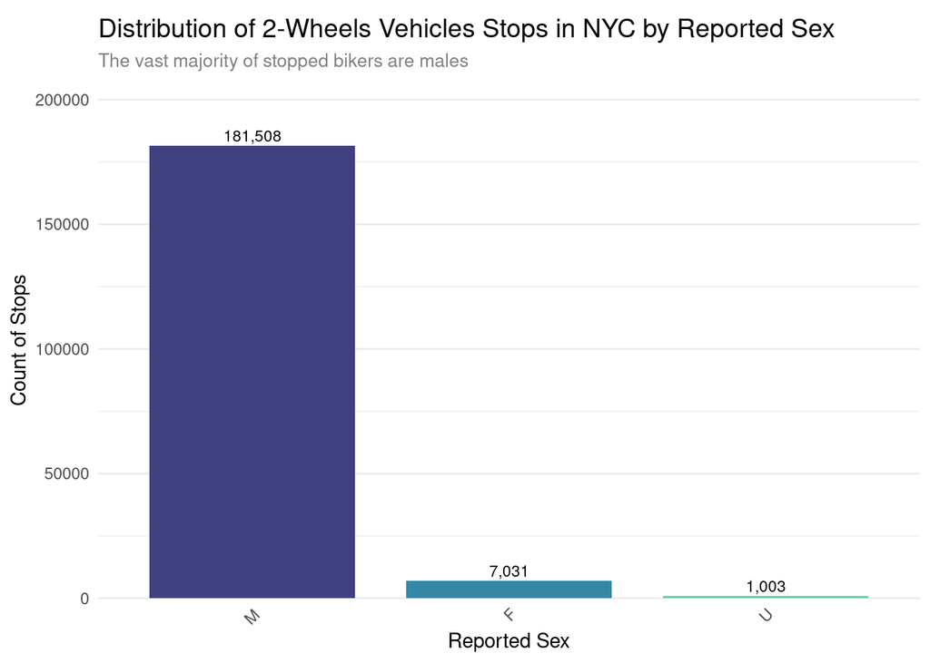

```r
plot_univariate_cat(
  DF = vehstops,
  FEATURE = sex,
  X_LABEL = "Reported Sex",
  TITLE = "Distribution of 2-Wheels Vehicles Stops in NYC by Reported Sex",
  SUBTITLE = "The vast majority of stopped bikers are males",
  order_by = "freq"
)
```

What can we say?

- **Key finding**: The data exhibits extreme class imbalance. “Male” (M) drivers represent the overwhelming majority of enforcement stops (approximately $96\%$), while “Female” (F) and “Unknown” (U) represent a negligible fraction of the total volume.
- **Interpretation**: This is a reflection of the driver demographic being targeted.
- **Comment**: Because the skew is so profound, `sex` will inevitably become a high-importance feature in any model we train.
- **Proposed Action**: We are going to investigate this predictor further. First, we are going to use correlation matrix (in the bivariate EDA) to see if sex is highly correlated with other variables. Then, we ensure to use stratified sampling (preserving the M/F/U ratio in both sets) for fitting and testing.

### Reported Ethnicity

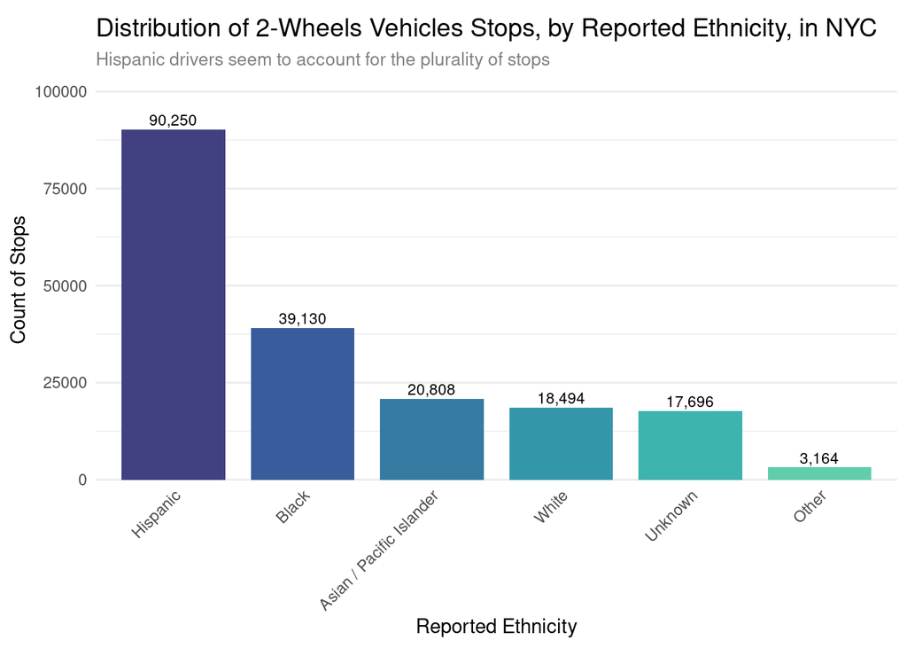

```r
plot_univariate_cat(
  DF = vehstops,
  FEATURE = ethnicity,
  X_LABEL = "Reported Ethnicity",
  TITLE = "Distribution of 2-Wheels Vehicles Stops, by Reported Ethnicity, in NYC",
  SUBTITLE = "Hispanic drivers seem to account for the plurality of stops",
  order_by = "freq"
)
```

What can we say?

- **Key finding**: The distribution is heavily skewed towards hispanic and black subjects. The “Unknown” category is also statistically important, mirroring the patterns we observed with age.
- **Interpretation**: This data does not reflect a random sampling of the driving population. The high concentration of specific demographics suggests that either (a) the geographic areas targeted for enforcement have high Hispanic populations, or (b) the specific types of vehicles being monitored are disproportionately staffed by this demographic.
- **Comment**: Because the distribution is so imbalanced, a machine learning model will probably use “ethnicity” to predict stops. In this case it “learns” that a stop is more likely for one group over another based on this pattern.
- **Proposed Action**: Before including ethnicity in our regression, we perform a correlation check against geographical and time related predictors. Also, we will stratify the splits based also on this predictor.

# Bivariate EDA

## Categorical Association of Binary Response vs. Categorical Predictors

When dealing with a dataset of this size, traditional p-values from chi-squared tests become meaningless. To get around this, we use Cramer’s V to measure effect size (association).

Because of how the `table()` function works in R, we can also include integer predictors like `hour` and `age`: they do not take truly continuous values in this dataset, so treating each integer as its own category is valid.

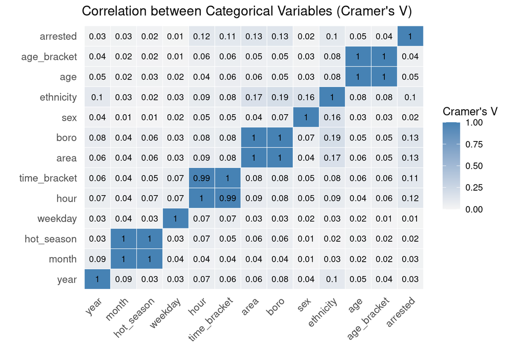

```r
# Excluding doy (redundant) and dow (we use weekday instead)
columns <- c(
  "year", "month", "hot_season", "weekday",
  "hour", "time_bracket",
  "area", "boro",
  "sex", "ethnicity", "age", "age_bracket",
  "arrested"
  )

plot_categorical_correlation(
  DF = vehstops,
  FEATURES = columns,
  TITLE = "Correlation between Categorical Variables (Cramer's V)"
)
```

What can we say?

- **Key finding**: The association matrix reveals that the only predictors showing a noticeable signal with `arrested` are `ethnicity` ($0.1$), `hour` / `time_bracket` ($0.11$), `area` ($0.13$), and `boro` ($0.13$). Conversely, demographic features such as `sex` ($0.02$) and `age` / `age_bracket` ($0.04$) share negligible pairwise associations with the target. The matrix highlights a moderate association between these top predictors, specifically between
  - the geographic and temporal blocks `area`/`boro` $\leftrightarrow$ `hour` / `time_bracket` (Cramer’s V of $0.08$),
  - between `ethnicity` $\leftrightarrow$ `area`/`boro` ($0.17$ to $0.19$), and
  - between `ethnicity` $\leftrightarrow$ `sex` ($0.16$).
- **Interpretation**: Temporal and spatial signals carry the strongest single impact when predicting an arrest, while motorist demographics are less informative as standalone predictors. However, the $0.08$ association between the main spatial and temporal features indicates the volume of stops are non-uniformly distributed across time and space. In other words, this suggests an underlying interaction between these two classes of predictors.
- **Comment**: Because **no single predictor strongly correlates** with `arrested`, **models relying purely on main effects will likely underfit** the data. The intersection of geography and time is where the true narrative of police behavior resides, as patrol priorities and ridership composition (such as delivery workers vs. overnight riders) change depending on the borough and hour. Surfacing patterns of excessive enforcement requires us to model these blocks conditionally rather than treating them as entirely independent factors.
- **Proposed Action**: We will focus our predictive models on the spatial and temporal axes by retaining `area` and `time_bracket` as our primary drivers. Possibly, we can try to capture the interaction term (`area` $\times$ `time_bracket`) in our logistic regression. This approach will allow us to test if the probability of arrest spikes during specific hours in specific areas.

## Correlation of Binary Response vs. Numerical Predictors

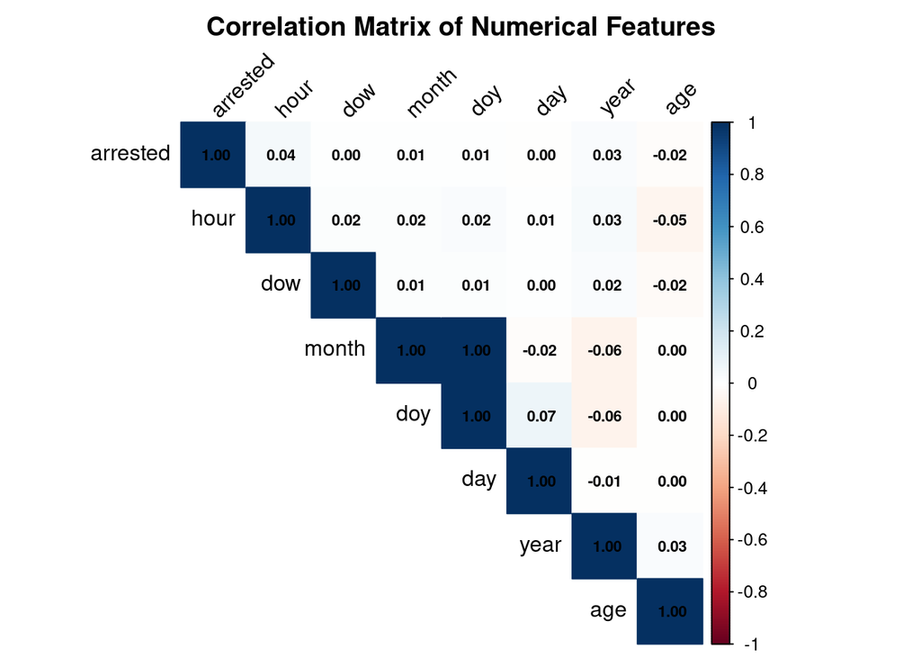

```r
# Ignoring Latitude and Longitude
numerical_cols <- c(
  "arrested",
  "year", "month", "day", "dow", "doy", "hour",
  "age"
  )

cor_matrix <- cor(vehstops[, numerical_cols], use = "complete.obs")

corrplot(cor_matrix, method = "color", type = "upper",
         order = "hclust", addCoef.col = "black", number.cex = 0.7,
         tl.col = "black", tl.srt = 45,
         title = "Correlation Matrix of Numerical Features",
         mar = c(0, 0, 2, 0))
```

What can we say? The target has no particularly important numerical correlation with any of the numerical predictors.

## Geospatial Features

### Area

```r
ratio_by_cat(
  vehstops, arrested, area,
  "Area", "Arrest Rate (%)", "Arrest Ratio by Area for 2-Wheels Vehicles Stopped in NYC",
  style = "stack", legend_title = "Stop ended in arrest?",
  target_labels = c("No", "Yes"),
  subtitle = "This shows Increased Arrest Ratio in Low Volume Areas",
  label_vjust = 0.5,
  bar_width = 0.6,
  text_size = 2.5,
  aspect_ratio = 0.9
)
```

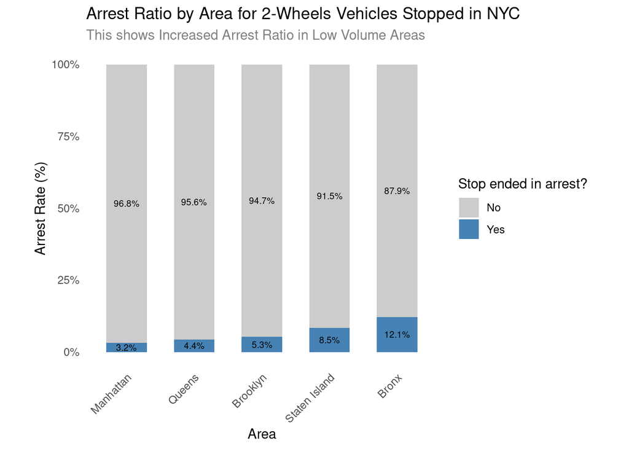

Let us look at the numbers too

```r
vehstops %>%
  group_by(area, arrested) %>%
  summarise(count = n(), .groups = "drop_last") %>%
  mutate(percentage = count / sum(count))
```

```
## # A tibble: 10 × 4
## # Groups:   area [5]
##    area          arrested count percentage
##    <chr>            <int> <int>      <dbl>
##  1 Bronx                0 26246     0.879
##  2 Bronx                1  3628     0.121
##  3 Brooklyn             0 53101     0.947
##  4 Brooklyn             1  2943     0.0525
##  5 Manhattan            0 49320     0.968
##  6 Manhattan            1  1608     0.0316
##  7 Queens               0 48963     0.956
##  8 Queens               1  2256     0.0440
##  9 Staten Island        0  1352     0.915
## 10 Staten Island        1   125     0.0846
```

What can we say? Remember that Staten Island and Bronx are the areas with the least volume of stops.

- **Key finding**: This plot reveals a noticeable disparity in the proportions of vehicle stops that end up in arrests for two-wheeled vehicles across New York City. The arrest rate ranges from a minimum of $3.2\%$ in Manhattan to a maximum of $12.1\%$ in the Bronx. This represents nearly a 4x increase in the relative probability of an arrest depending on the location of the encounter. Also, low-volume areas (Staten Island, Bronx) show arrest rates above the citywide average, while high-volume areas (Brooklyn, Queens) are closer to the global mean.
- **Interpretation**: For the Bronx ($N = 29,874$), the $12.1\%$ arrest rate is calculated from the 3,628 arrests, proving that the elevated rate is a robust signal. However, the $8.5\%$ arrest rate in Staten Island is derived from only 125 events ($n = 125$ out of $N = 1,477$), meaning our parameter estimation (for this area) will have a wider confidence interval and higher susceptibility to sampling noise. For the remaining areas, we have more stable signals.
- **Comment**: While the absolute majority of stops do not end in an arrest anywhere, the relative jump to a $12.1\%$ arrest rate in the Bronx is statistically and socially relevant. The plot reveals that the areas with the fewest total stops (Staten Island and the Bronx) yield the highest relative proportions of arrests. It highlights an interesting paradox where high-density, high-volume areas like Manhattan experience a massive volume of stops ($50,928$) but maintain a minimal arrest incidence. This could confirm that police behavior **vary** by territory.
- **Proposed Action**: We include `area` as a candidate predictor in our models, but also test `boro` as a finer-grained alternative. We are going to stratify this aspect of the data too.

### Borough

```r
ratio_by_cat(
  vehstops, arrested, boro,
  "Borough", "Arrest Rate (%)", "Arrest Ratio by Borough for 2-Wheels Vehicles Stopped in NYC",
  style = "stack", legend_title = "Stop ended in arrest?",
  target_labels = c("No", "Yes"),
  subtitle = "This confirms the Increased Arrest Ratio in Low Volume Areas",
  label_vjust = 0.5,
  bar_width = 0.8,
  text_size = 2.5
)
```

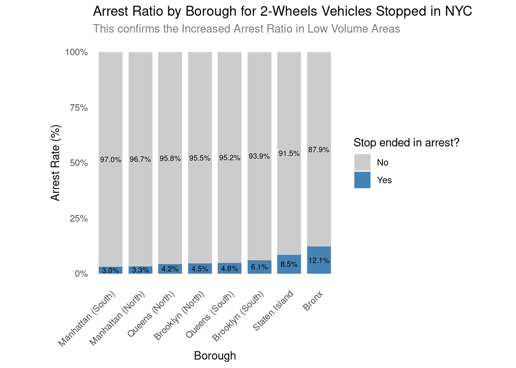

```r
vehstops %>%
  group_by(boro, arrested) %>%
  summarise(count = n(), .groups = "drop_last") %>%
  mutate(percentage = count / sum(count))
```

```
## # A tibble: 16 × 4
## # Groups:   boro [8]
##    boro              arrested count percentage
##    <chr>                <int> <int>      <dbl>
##  1 Bronx                    0 26246     0.879
##  2 Bronx                    1  3628     0.121
##  3 Brooklyn (North)         0 28187     0.955
##  4 Brooklyn (North)         1  1335     0.0452
##  5 Brooklyn (South)         0 24914     0.939
##  6 Brooklyn (South)         1  1608     0.0606
##  7 Manhattan (North)        0 27926     0.967
##  8 Manhattan (North)        1   945     0.0327
##  9 Manhattan (South)        0 21394     0.970
## 10 Manhattan (South)        1   663     0.0301
## 11 Queens (North)           0 33658     0.958
## 12 Queens (North)           1  1478     0.0421
## 13 Queens (South)           0 15305     0.952
## 14 Queens (South)           1   778     0.0484
## 15 Staten Island            0  1352     0.915
## 16 Staten Island            1   125     0.0846
```

What can we say?

- **Key finding**: Disaggregating (some of) the geographic data into finer regions preserves the overall ranking but reveals a minor intra-borough variance. The Bronx ($12.1\%$, $3628$ arrests) and Staten Island ($8.5\%$, $125$ arrests) remain the primary “outliers”, while the separated regions display a steady gradient ranging from a minimum of $3.0\%$ in Manhattan (South) to a maximum of $6.1\%$ in Brooklyn (South).
- **Interpretation**: This fine-grained visualization confirms that the macro patterns (observed previously) are robust. Within the boroughs that were split, we observe small localized shifts. This suggests that this predictor could explain even better the association with arrests.
- **Proposed Action**: We should perform a test on nested logistic models. This aims to see whether a greater division achieves a statistically significant improvement over the simpler area-based model. In case the change is not significant, we will opt for a parsimonious model.

We will need to choose between one or the other.

### Latitude and Longitude for Stop Rate

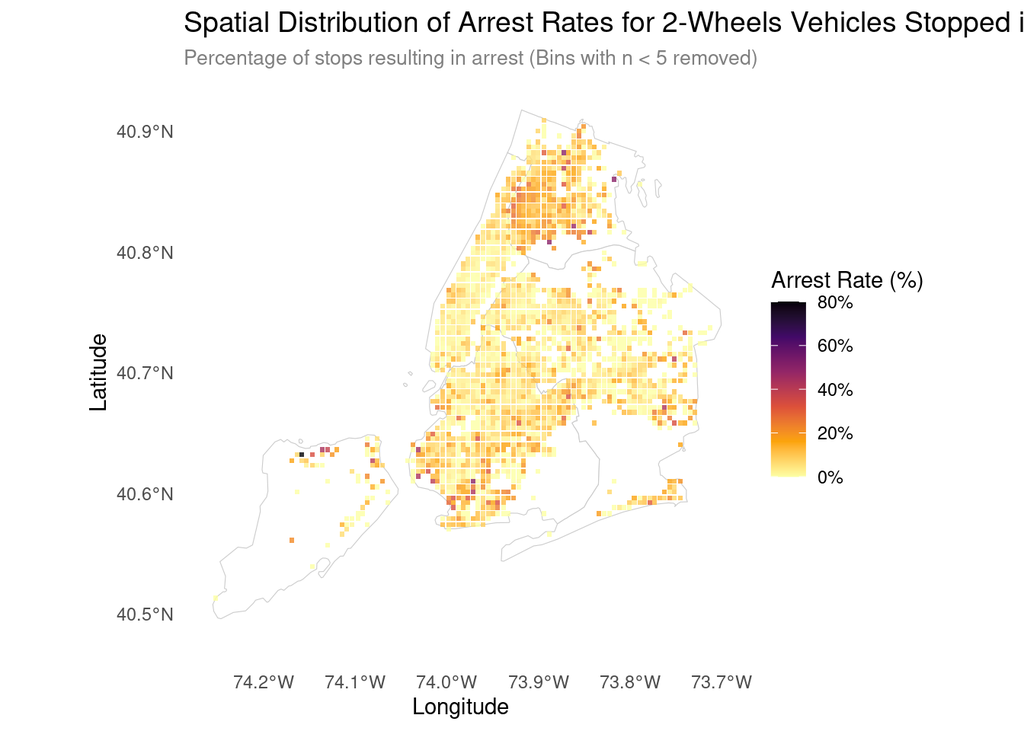

```r
nyc_map <- counties(state = "NY", cb = TRUE) %>%
  filter(NAME %in% c("Bronx", "Kings", "New York", "Queens", "Richmond"))

bins <- 100
lon_breaks <- seq(-74.26, -73.71, length.out = bins + 1)
lat_breaks <- seq(40.48, 40.92, length.out = bins + 1)

grid_sum_rate <- vehstops %>%
  filter(!is.na(longitude), !is.na(latitude), !is.na(arrested)) %>%
  mutate(
    xbin = cut(longitude, breaks = lon_breaks, include.lowest = TRUE, right = FALSE),
    ybin = cut(latitude, breaks = lat_breaks, include.lowest = TRUE, right = FALSE)
  ) %>%
  mutate(
    x = as.numeric(gsub(".*\\[(.*),.*", "\\1", xbin)) + (lon_breaks[2] - lon_breaks[1])/2,
    y = as.numeric(gsub(".*\\[(.*),.*", "\\1", ybin)) + (lat_breaks[2] - lat_breaks[1])/2
  ) %>%
  group_by(x, y) %>%
  summarise(
    total_stops = n(),
    arrest_rate = mean(arrested == 1),
    .groups = "drop"
  ) %>%
  filter(total_stops >= 5)

ggplot() +
  geom_sf(data = nyc_map, fill = "white", color = "grey80", linewidth = 0.2) +
  geom_tile(data = grid_sum_rate, aes(x, y, fill = arrest_rate), alpha = 0.8) +
  scale_fill_viridis_c(
    labels = scales::percent,
    name = "Arrest Rate (%)",
    option = "inferno",
    direction = -1
  ) +
  coord_sf(xlim = c(-74.26, -73.71), ylim = c(40.48, 40.92)) +
  theme_minimal() +
  theme(
    panel.grid = element_blank(),
    plot.title = element_text(size = 14),
    plot.subtitle = element_text(color = "grey50", size = 10)
  ) +
  labs(
    title = "Spatial Distribution of Arrest Rates for 2-Wheels Vehicles Stopped in NYC",
    subtitle = "Percentage of stops resulting in arrest (Bins with n < 5 removed)",
    x = "Longitude",
    y = "Latitude"
  )
```

What can we say?

- **Key finding**: The visualization displays highly localized hot spots, particularly in the Bronx, southern Brooklyn and northern Staten Island. Here, in fact, some specific bins show arrest rates climbing well above $40\%$ and even reaching up to $80\%$.
- **Interpretation**: While this highlights a great geographic heterogeneity, it exposes a critical limitation regarding model integration because spatial data violates the assumption of independence.

## Time related features

### Year

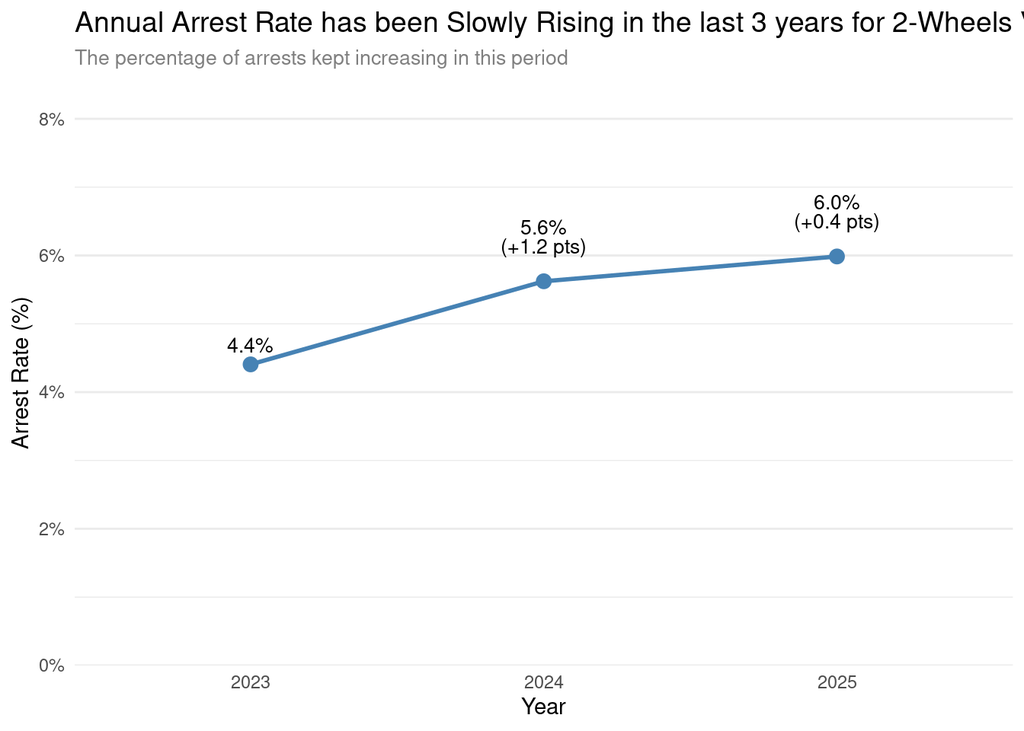

```r
arrest_trends <- vehstops %>%
  filter(!is.na(year), !is.na(arrested)) %>%
  group_by(year) %>%
  summarise(
    total_stops = n(),
    arrests = sum(arrested == 1),
    rate = arrests / total_stops,
    .groups = 'drop'
  ) %>%
  arrange(year) %>%
  mutate(
    prev_rate = lag(rate),
    delta = (rate - prev_rate) * 100,
    label_text = ifelse(
      is.na(prev_rate),
      scales::percent(rate, accuracy = 0.1),
      paste0(scales::percent(rate, accuracy = 0.1),
             "\n(", ifelse(delta > 0, "+", ""), round(delta, 1), " pts)")
    )
  )

ggplot(arrest_trends, aes(x = factor(year), y = rate, group = 1)) +
  geom_line(color = "steelblue", linewidth = 1) +
  geom_point(color = "steelblue", size = 3) +
  geom_text(aes(label = label_text), vjust = -0.8, size = 3.5, lineheight = 0.8) +
  scale_y_continuous(
    labels = scales::percent,
    limits = c(0, max(arrest_trends$rate) * 1.3),
    expand = expansion(mult = c(0, 0.1))
  ) +
  theme_minimal() +
  theme(
    panel.grid.major.x = element_blank(),
    plot.title = element_text(size = 14),
    plot.subtitle = element_text(size = 10, color = "grey50")
  ) +
  labs(
    title = "Annual Arrest Rate has been Slowly Rising in the last 3 years for 2-Wheels Vehicles Stopped in NYC",
    subtitle = "The percentage of arrests kept increasing in this period",
    x = "Year", y = "Arrest Rate (%)"
  )
```

What can we say?

- **Key finding**: The line chart displays the trajectory (of the annual arrest rate for two-wheeled vehicles over a three-year period) revealing an upward trend. The proportion of stops resulting in an arrest rose from $4.4\%$ in 2023 to $5.6\%$ in 2024 (a jump of $+1.2$ percentage points), followed by a slighter increase to $6.0\%$ in 2025 (an additional $+0.4$ percentage points).
- **Interpretation**: From a time related perspective, this demonstrates the probability of an arrest given a stop is evolving over time. In a predictive framework, this upward drift means that older data points (such as those from 2023) may underestimate current arrest probabilities.
- **Proposed Action**: We should check for an association effect between time and geography by plotting these three-year trends faceted by area/borough to see if the growth is uniform. Furthemore, we may include `year` as a categorical predictor to absorb the yearly trend.

### Month and Hot Season

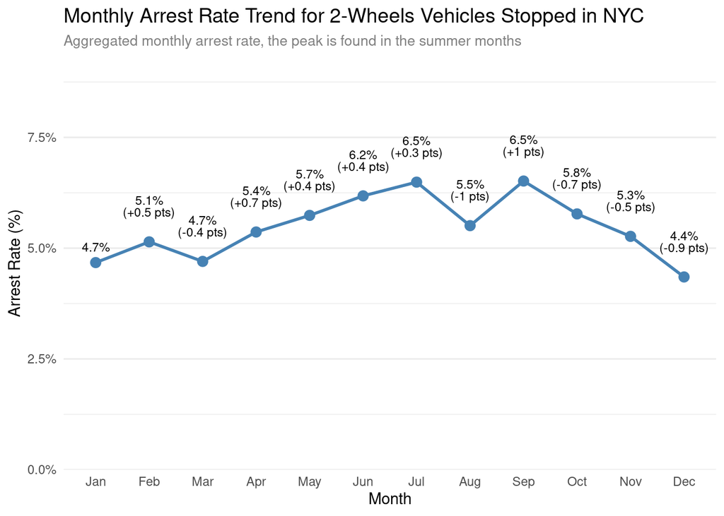

```r
monthly_arrest_data <- vehstops %>%
  filter(!is.na(month), !is.na(arrested)) %>%
  group_by(month) %>%
  summarise(
    total_stops = n(),
    arrests = sum(arrested == 1),
    rate = arrests / total_stops,
    .groups = "drop"
  ) %>%
  mutate(month = factor(month, levels = 1:12)) %>%
  arrange(month) %>%
  mutate(
    prev_rate = lag(rate),
    delta = (rate - prev_rate) * 100,
    label_text = ifelse(
      is.na(prev_rate),
      scales::percent(rate, accuracy = 0.1),
      paste0(scales::percent(rate, accuracy = 0.1),
             "\n(", ifelse(delta > 0, "+", ""), round(delta, 1), " pts)")
    )
  )

monthly_arrest_data %>%
  ggplot(aes(x = month, y = rate, group = 1)) +
  geom_line(color = "steelblue", linewidth = 1) +
  geom_point(color = "steelblue", size = 3) +
  geom_text(aes(label = label_text), vjust = -1.2, size = 3, lineheight = 0.8) +
  scale_x_discrete(labels = month.abb) +
  scale_y_continuous(
    labels = scales::percent,
    limits = c(0, max(monthly_arrest_data$rate) * 1.3),
    expand = expansion(mult = c(0, 0.1))
  ) +
  theme_minimal() +
  theme(
    panel.grid.major.x = element_blank(),
    plot.title = element_text(size = 14),
    plot.subtitle = element_text(color = "grey50", size = 10)
  ) +
  labs(
    title = "Monthly Arrest Rate Trend for 2-Wheels Vehicles Stopped in NYC",
    subtitle = "Aggregated monthly arrest rate, the peak is found in the summer months",
    x = "Month",
    y = "Arrest Rate (%)"
  )
```

What can we say?

- **Key finding**: The monthly arrest rate line chart describes a clear intra-year pattern. The arrest rates climb up from March and peak at $6.5\%$ in July and September. Then, they drop sharply during autumn and winter months to a minimum of $4.4\%$ in December.
- **Interpretation**: The surge in the arrest rate during warmer months indicates that enforcement volume increases along with rider volume, or that specific initiatives are altering the probability of an arrest.
- **Proposed Action**: We try to encode seasonality using the `hot_season` binary predictor.

What about `hot_season`?

```r
ratio_by_cat(
  vehstops, arrested, hot_season,
  "Hot Season", "Arrest Rate (%)", "Arrest Ratio by Season for 2-Wheels Vehicles Stopped in NYC",
  style = "stack", legend_title = "Stop ended in arrest?",
  target_labels = c("No", "Yes"),
  subtitle = "For 2-Wheels Vehicles it shows Increased Arrest Ratio during Hot Months",
  label_vjust = 0.5,
  text_size = 2.5,
  bar_width = 0.7
)
```

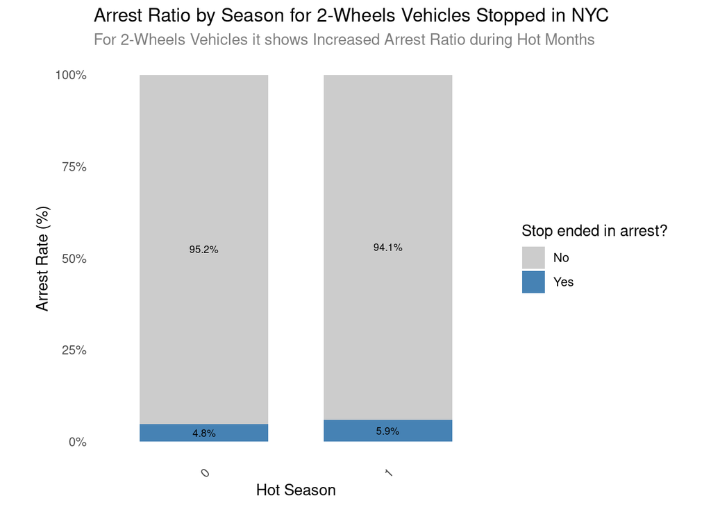

What can we say?

- **Key finding**: In the cold season, the arrest rate stays at $4.8\%$, whereas during the hot season, the probability of a stop ending in an arrest climbs to $5.9\%$.
- **Comment**: This visualization acts as a feature engineering verification step, confirming that compressing the 12 calendar months into a simplified variable preserves a robust signal. The $1.1$ percentage point difference, confirms that seasonal enforcement behavior can be captured via a single binary flag.
- **Proposed Action**: Before committing exclusively to this binary feature in our final production model, we should evaluate if this oversimplifies the data.